# Analysis of the 2016 Election

**By John Clements**

The outcome of the 2016 presidential election was surprising to many people, particularly to those not familiar with historical polling error sizes. In order to determine some of the underlying factors influencing voting patterns, I downloaded the 2015 5-year estimates American Community Survey (the ACS is a survey of American households administered by the Census Bureau) from the Census Bureau website and aggregated it up from the Census Tract (sub-county geographical units defined by the Census Bureau) level to the county and state level. I chose the 2015 ACS, as opposed to the 2016 ACS because it is information that was available prior to the election, while the 2016 ACS wouldn’t have been available at the time of the election. I then got election data at the county level from https://cutt.ly/YTCa9x and at the state level from the MIT Election Data and Science Lab. I used *vlookup* in Excel to quickly add in a ‘state’ column to the county level election results before loading into this notebook for my formatting purposes. I then merged them together and did some exploratory analysis using Principal Component Analysis and K-means clustering to see if any interesting groupings of states appeared. Following some exploratory analysis, I used logistic regression utilizing forwards and backwards step-wise variable selection to eliminate unimportant variables. I decided on logistic regression as opposed to other classification techniques because of it’s interpretable and after estimating the models I investigated the relationships between the independent variables and electoral outcomes. The coefficients of the models are consistent with Clinton performing better in less white areas, urban areas, and areas with higher per capita incomes, as well as areas with higher poverty rates.

# **I. Creating the State and County Level Data Sets**

It would be nice if data sets were ready for exploration and modeling as soon as they’re downloaded, but unfortunately they often need to be reformatted and cleaned before the fun can begin. This is what I do in this section.

## **A. Getting the Demographic Data from the 2015 American Community Survey**

First, the 2015 American Community Survey needs to be loaded in. There are 74,001 rows (Census Tracts) and 37 columns for variables on demographic, economic, and other types of data.

```r
# loads the dplyr library for data manipulation
library(dplyr)
# reads in the 2015 American Community Survey .csv file
acs = read.csv('acs2015_census_tract_data.csv')

# prints out the dimensions of the 2015 ACS and it shows there are 74001 rows and 37 columns
dim(acs)
```

```
## [1] 74001    37
```

```r
# prints out the column names of the acs
names(acs)
```

```
##  [1] "CensusTract"     "State"           "County"
##  [4] "TotalPop"        "Men"             "Women"
##  [7] "Hispanic"        "White"           "Black"
## [10] "Native"          "Asian"           "Pacific"
## [13] "Citizen"         "Income"          "IncomeErr"
## [16] "IncomePerCap"    "IncomePerCapErr" "Poverty"
## [19] "ChildPoverty"    "Professional"    "Service"
## [22] "Office"          "Construction"    "Production"
## [25] "Drive"           "Carpool"         "Transit"
## [28] "Walk"            "OtherTransp"     "WorkAtHome"
## [31] "MeanCommute"     "Employed"        "PrivateWork"
## [34] "PublicWork"      "SelfEmployed"    "FamilyWork"
## [37] "Unemployment"
```

```r
# prints out the first 5 entries showing that lots of the variables are in percentages and need
# to be converted to absolute numbers before aggregating up to the county and state level
head(acs, n = 3)
```

|  | CensusTract | State | County | TotalPop | Men | Women | Hispanic | White | Black | Native | Asian | Pacific | Citizen | Income | IncomeErr | IncomePerCap | IncomePerCapErr | Poverty | ChildPoverty | Professional | Service | Office | Construction | Production | Drive | Carpool | Transit | Walk | OtherTransp | … |
| --- | --- | --- | --- | --- | --- | --- | --- | --- | --- | --- | --- | --- | --- | --- | --- | --- | --- | --- | --- | --- | --- | --- | --- | --- | --- | --- | --- | --- | --- | --- |
| 1 | 1001020100 | Alabama | Autauga | 1948 | 940 | 1008 | 0.9 | 87.4 | 7.7 | 0.3 | 0.6 | 0.0 | 1503 | 61838 | 11900 | 25713 | 4548 | 8.1 | 8.4 | 34.7 | 17.0 | 21.3 | 11.9 | 15.2 | 90.2 | 4.8 | 0 | 0.5 | 2.3 | … |
| 2 | 1001020200 | Alabama | Autauga | 2156 | 1059 | 1097 | 0.8 | 40.4 | 53.3 | 0.0 | 2.3 | 0.0 | 1662 | 32303 | 13538 | 18021 | 2474 | 25.5 | 40.3 | 22.3 | 24.7 | 21.5 | 9.4 | 22.0 | 86.3 | 13.1 | 0 | 0.0 | 0.7 | … |
| 3 | 1001020300 | Alabama | Autauga | 2968 | 1364 | 1604 | 0.0 | 74.5 | 18.6 | 0.5 | 1.4 | 0.3 | 2335 | 44922 | 5629 | 20689 | 2817 | 12.7 | 19.7 | 31.4 | 24.9 | 22.1 | 9.2 | 12.4 | 94.8 | 2.8 | 0 | 0.0 | 0.0 | … |

After checking for missing values, I found there are numerous missing values that need to be filled in.

```r
# creates a single variable for the State and County names for easy grouping since County names
# can repeat in multiple states
acs$StateCounty = with(acs, paste0(State, '_', County))

# prints the number of missing values in each column
for (var in colnames(acs)){
    if (sum(is.na(acs[[var]])) > 0) print(paste(var, sum(is.na(acs[[var]]))))
}
```

```
## [1] "Hispanic 690"
## [1] "White 690"
## [1] "Black 690"
## [1] "Native 690"
## [1] "Asian 690"
## [1] "Pacific 690"
## [1] "Income 1100"
## [1] "IncomeErr 1100"
## [1] "IncomePerCap 740"
## [1] "IncomePerCapErr 740"
## [1] "Poverty 835"
## [1] "ChildPoverty 1118"
## [1] "Professional 807"
## [1] "Service 807"
## [1] "Office 807"
## [1] "Construction 807"
## [1] "Production 807"
## [1] "Drive 797"
## [1] "Carpool 797"
## [1] "Transit 797"
## [1] "Walk 797"
## [1] "OtherTransp 797"
## [1] "WorkAtHome 797"
## [1] "MeanCommute 949"
## [1] "PrivateWork 807"
## [1] "PublicWork 807"
## [1] "SelfEmployed 807"
## [1] "FamilyWork 807"
## [1] "Unemployment 802"
```

It appeared there are some Census Tracts with no data at all, which was especially a problem in Puerto Rico. Other missing observations seemed to be in rows with plenty of other information.

```r
# creates a dataframe of the rows with missing values in any column
missing_data <- acs[rowSums(is.na(acs)) > 0,]
# prints out the first and last 6 rows with missing values to get an idea of the missing values
head(missing_data)
```

|  | CensusTract | State | County | TotalPop | Men | Women | Hispanic | White | Black | Native | Asian | Pacific | Citizen | Income | IncomeErr | IncomePerCap | IncomePerCapErr | Poverty | ChildPoverty | Professional | Service | Office | Construction | Production | Drive | Carpool | Transit | Walk | OtherTransp | … |
| --- | --- | --- | --- | --- | --- | --- | --- | --- | --- | --- | --- | --- | --- | --- | --- | --- | --- | --- | --- | --- | --- | --- | --- | --- | --- | --- | --- | --- | --- | --- |
| 44 | 1003990000 | Alabama | Baldwin | 0 | 0 | 0 | NA | NA | NA | NA | NA | NA | 0 | NA | NA | NA | NA | NA | NA | NA | NA | NA | NA | NA | NA | NA | NA | NA | NA | … |
| 107 | 1015981901 | Alabama | Calhoun | 4 | 4 | 0 | 0.0 | 100.0 | 0.0 | 0.0 | 0.0 | 0 | 4 | NA | NA | NA | NA | 0.0 | NA | NA | NA | NA | NA | NA | NA | NA | NA | NA | NA | … |
| 108 | 1015981902 | Alabama | Calhoun | 0 | 0 | 0 | NA | NA | NA | NA | NA | NA | 0 | NA | NA | NA | NA | NA | NA | NA | NA | NA | NA | NA | NA | NA | NA | NA | NA | … |
| 109 | 1015981903 | Alabama | Calhoun | 0 | 0 | 0 | NA | NA | NA | NA | NA | NA | 0 | NA | NA | NA | NA | NA | NA | NA | NA | NA | NA | NA | NA | NA | NA | NA | NA | … |
| 598 | 1081040700 | Alabama | Lee | 4793 | 2053 | 2740 | 3.1 | 85.4 | 6.8 | 0.2 | 3.8 | 0 | 4690 | 22935 | 5974 | 4122 | 788 | 63.2 | NA | 23.8 | 33.8 | 25.9 | 8.2 | 8.3 | 59.9 | 7.6 | 4.0 | 21.2 | 2.6 | … |
| 599 | 1081040800 | Alabama | Lee | 3310 | 1801 | 1509 | 1.6 | 76.6 | 9.5 | 1.2 | 10.9 | 0 | 2959 | 8160 | 3741 | 7068 | 1491 | 80.2 | NA | 54.1 | 31.2 | 13.1 | 0.4 | 1.2 | 52.6 | 10.8 | 4.1 | 27.6 | 4.9 | … |

```r
tail(missing_data)
```

|  | CensusTract | State | County | TotalPop | Men | Women | Hispanic | White | Black | Native | Asian | Pacific | Citizen | Income | IncomeErr | IncomePerCap | IncomePerCapErr | Poverty | ChildPoverty | Professional | Service | Office | Construction | Production | Drive | Carpool | Transit | Walk | OtherTransp | … |
| --- | --- | --- | --- | --- | --- | --- | --- | --- | --- | --- | --- | --- | --- | --- | --- | --- | --- | --- | --- | --- | --- | --- | --- | --- | --- | --- | --- | --- | --- | --- |
| 73888 | 72133990000 | Puerto Rico | Santa Isabel | 0 | 0 | 0 | NA | NA | NA | NA | NA | NA | 0 | NA | NA | NA | NA | NA | NA | NA | NA | NA | NA | NA | NA | NA | NA | NA | NA | … |
| 73927 | 72137990000 | Puerto Rico | Toa Baja | 0 | 0 | 0 | NA | NA | NA | NA | NA | NA | 0 | NA | NA | NA | NA | NA | NA | NA | NA | NA | NA | NA | NA | NA | NA | NA | NA | … |
| 73958 | 72143990000 | Puerto Rico | Vega Alta | 0 | 0 | 0 | NA | NA | NA | NA | NA | NA | 0 | NA | NA | NA | NA | NA | NA | NA | NA | NA | NA | NA | NA | NA | NA | NA | NA | … |
| 73972 | 72145990000 | Puerto Rico | Vega Baja | 0 | 0 | 0 | NA | NA | NA | NA | NA | NA | 0 | NA | NA | NA | NA | NA | NA | NA | NA | NA | NA | NA | NA | NA | NA | NA | NA | … |
| 73975 | 72147990000 | Puerto Rico | Vieques | 0 | 0 | 0 | NA | NA | NA | NA | NA | NA | 0 | NA | NA | NA | NA | NA | NA | NA | NA | NA | NA | NA | NA | NA | NA | NA | NA | … |
| 73990 | 72151990000 | Puerto Rico | Yabucoa | 0 | 0 | 0 | NA | NA | NA | NA | NA | NA | 0 | NA | NA | NA | NA | NA | NA | NA | NA | NA | NA | NA | NA | NA | NA | NA | NA | … |

Since Puerto Rico lacks electoral votes I excluded it from my analysis, dropping some missing observations. I also dropped Census Tracts where the population is 0 because they appear to have only empty columns. There were still missing observations to be dealt with after dropping the empty rows, so I chose to impute them.

```r
# removes Puerto Rico and Census Tracts with empty total populations from acs in a new
# dataframe
fill_acs = acs[!(acs$State == 'Puerto Rico' | acs$TotalPop == 0),]
# drops the CensusTract because it isn't important to the analysis
fill_acs = fill_acs %>%
    select(-CensusTract)
# prints the number of missing values in each column
for (var in colnames(fill_acs)){
    if (sum(is.na(fill_acs[[var]])) > 0) print(paste(var, sum(is.na(fill_acs[[var]]))))
}
```

```
## [1] "Income 398"
## [1] "IncomeErr 398"
## [1] "IncomePerCap 48"
## [1] "IncomePerCapErr 48"
## [1] "Poverty 144"
## [1] "ChildPoverty 424"
## [1] "Professional 116"
## [1] "Service 116"
## [1] "Office 116"
## [1] "Construction 116"
## [1] "Production 116"
## [1] "Drive 106"
## [1] "Carpool 106"
## [1] "Transit 106"
## [1] "Walk 106"
## [1] "OtherTransp 106"
## [1] "WorkAtHome 106"
## [1] "MeanCommute 254"
## [1] "PrivateWork 116"
## [1] "PublicWork 116"
## [1] "SelfEmployed 116"
## [1] "FamilyWork 116"
## [1] "Unemployment 111"
```

I decided to impute missing observations with the mean value in the column within the same county, since there are multiple Census Tracts within a county. This is under the assumption that areas within a county are more similar to each other than the state or total US level. However, after this process, there are still 3 missing values; one in ‘Income’, ‘IncomeErr’, and ‘ChildPoverty’.

```r
# this loops through the numeric columns in fill_acs and then loops through the rows with
# missing values and then imputes the missing values with the mean for the subset of rows in
# in the same StateCounty subset
for (i in which(sapply(fill_acs, is.numeric))) {
    for (j in which(is.na(fill_acs[, i]))) {
        # sets the missing value at row j and in column i to the mean of the non-missing values
        # in column i that are in the same county in the same state
        fill_acs[j, i] = mean(
            fill_acs[fill_acs[, 'StateCounty'] ==  fill_acs[j, 'StateCounty'], i], na.rm = TRUE)
    }
}

# prints the number of missing values in each column
for (var in colnames(fill_acs)){
    if (sum(is.na(fill_acs[[var]])) > 0) print(paste(var, sum(is.na(fill_acs[[var]]))))
}
```

```
## [1] "Income 1"
## [1] "IncomeErr 1"
## [1] "ChildPoverty 1"
```

I used the state averages for the last 3 missing values.

Some of the variables were in percentage terms, which would have made aggregating up from the Census Tract level difficult. To fix this, I translated the percentages to proportions, and multiplied them by the total population of the Census Tract, then rounded to the nearest integer (you can’t have fractions of a person). I got a total income for the Census Tracts by multiplying the per capita income by the total population of the Census Tract and did the same for the commute time variable. This allowed all the variables to be summed up giving the total number of persons in a given demographic, professional, etc. group and the total income and commute time at the state and county levels. These variables were then divided by the population at the state or county level, so they became proportions, income per capita, and average commute time per person at the state and county levels.

```r
# does the same thing as the other loop but it sets the missing values to the state average
# because these entries with missing values likely have no other observations in the same
# county
for (i in c('Income', 'IncomeErr', 'ChildPoverty')) {
    for (j in which(is.na(fill_acs[, i]))) {
        fill_acs[j, i] = mean(fill_acs[fill_acs[, 'State'] ==  fill_acs[j, 'State'], i],
                              na.rm = TRUE)
    }
}

# prints the number of missing values in each column if there are any
for (var in colnames(fill_acs)){
    if (sum(is.na(fill_acs[[var]])) > 0) print(paste(var, sum(is.na(fill_acs[[var]]))))
}

# creates a list containing the soon to be redundant income variables and which will be
# appended with variables to drop
vars_to_drop = c('Income', 'IncomeErr', 'IncomePerCap', 'IncomePerCapErr');

# this loop goes through variables that are in percentage terms and then turns them to absolute
# numbers for later aggregation up to the county and state level
for (var in c('Hispanic', 'White', 'Black', 'Native', 'Asian', 'Pacific', 'Poverty',
       'ChildPoverty', 'Professional', 'Service', 'Office', 'Construction',
       'Production', 'Drive', 'Carpool', 'Transit', 'Walk', 'OtherTransp',
       'WorkAtHome', 'PrivateWork', 'PublicWork', 'SelfEmployed', 'FamilyWork',
        'Unemployment')){
    # creates a new column from the old variable that turns the percentage into a proportion
    # then multiplies by the number of people in the census tract and then rounds that to the
    # nearest whole number because you cannot have fractions of a person
    fill_acs[[paste0(var,'_')]] = round((fill_acs[[var]] / 100) * fill_acs$TotalPop)
    # adds the old variable to the list to drop after the new variables are created
    vars_to_drop = c(vars_to_drop, var)
}

# creates a variable that when the state and county level aggregation occurs and each
# variable is divided by TotalPop will provide per capita income
fill_acs$income_weighted = fill_acs$IncomePerCap * fill_acs$TotalPop

# creates a variable that when the state and county level aggregation occurs and each
# variable is divided by TotalPop will provide per capita income
fill_acs$MeanCommute = fill_acs$MeanCommute * fill_acs$TotalPop

# drops the redundant variables
fill_acs = fill_acs[ , !(names(fill_acs) %in% vars_to_drop)]

head(fill_acs)
```

|  | State | County | TotalPop | Men | Women | Citizen | MeanCommute | Employed | StateCounty | Hispanic_ | White_ | Black_ | Native_ | Asian_ | Pacific_ | Poverty_ | ChildPoverty_ | Professional_ | Service_ | Office_ | Construction_ | Production_ | Drive_ | Carpool_ | Transit_ | Walk_ | OtherTransp_ | WorkAtHome_ | PrivateWork_ | … |
| --- | --- | --- | --- | --- | --- | --- | --- | --- | --- | --- | --- | --- | --- | --- | --- | --- | --- | --- | --- | --- | --- | --- | --- | --- | --- | --- | --- | --- | --- | --- |
| 1 | Alabama | Autauga | 1948 | 940 | 1008 | 1503 | 48700.0 | 943 | Alabama_Autauga | 18 | 1703 | 150 | 6 | 12 | 0 | 158 | 164 | 676 | 331 | 415 | 232 | 296 | 1757 | 94 | 0 | 10 | 45 | 41 | 1502 | … |
| 2 | Alabama | Autauga | 2156 | 1059 | 1097 | 1662 | 50450.4 | 753 | Alabama_Autauga | 17 | 871 | 1149 | 0 | 50 | 0 | 550 | 869 | 481 | 533 | 464 | 203 | 474 | 1861 | 282 | 0 | 0 | 15 | 0 | 1660 | … |
| 3 | Alabama | Autauga | 2968 | 1364 | 1604 | 2335 | 58172.8 | 1373 | Alabama_Autauga | 0 | 2211 | 552 | 15 | 42 | 9 | 377 | 585 | 932 | 739 | 656 | 273 | 368 | 2814 | 83 | 0 | 0 | 0 | 74 | 1902 | … |
| 4 | Alabama | Autauga | 4423 | 2172 | 2251 | 3306 | 111901.9 | 1782 | Alabama_Autauga | 464 | 3662 | 164 | 71 | 0 | 0 | 93 | 71 | 1194 | 920 | 1194 | 385 | 725 | 3830 | 402 | 0 | 0 | 115 | 71 | 3348 | … |
| 5 | Alabama | Autauga | 10763 | 4922 | 5841 | 7666 | 266922.4 | 5037 | Alabama_Autauga | 75 | 7373 | 2669 | 0 | 409 | 0 | 1227 | 1884 | 5338 | 1528 | 1959 | 226 | 1701 | 9471 | 1130 | 0 | 0 | 65 | 97 | 7222 | … |
| 6 | Alabama | Autauga | 3851 | 1787 | 2064 | 2642 | 76249.8 | 1560 | Alabama_Autauga | 504 | 2807 | 458 | 0 | 0 | 0 | 555 | 843 | 932 | 674 | 1363 | 304 | 574 | 3185 | 266 | 0 | 0 | 231 | 173 | 3058 | … |

```r
# creates a variable that has the state level data by summing each variable at that level
X_state = fill_acs %>%
    select(-County) %>%
        select(-StateCounty) %>%
            group_by(State) %>%
                summarise_each(funs(sum))
# looks at the first and last 3 rows to check the appearance of the data
head(X_state, n = 3)
```

| State | TotalPop | Men | Women | Citizen | MeanCommute | Employed | Hispanic_ | White_ | Black_ | Native_ | Asian_ | Pacific_ | Poverty_ | ChildPoverty_ | Professional_ | Service_ | Office_ | Construction_ | Production_ | Drive_ | Carpool_ | Transit_ | Walk_ | OtherTransp_ | WorkAtHome_ | PrivateWork_ | PublicWork_ | SelfEmployed_ | FamilyWork_ | … |
| --- | --- | --- | --- | --- | --- | --- | --- | --- | --- | --- | --- | --- | --- | --- | --- | --- | --- | --- | --- | --- | --- | --- | --- | --- | --- | --- | --- | --- | --- | --- |
| Alabama | 4830620 | 2341093 | 2489527 | 3620994 | 118240501 | 2022325 | 193468 | 3205060 | 1270061 | 22234 | 58982 | 1579 | 919891 | 1304188 | 1547004 | 833125 | 1158498 | 488647 | 803405 | 4109059 | 455081 | 23369 | 59869 | 51884 | 131295 | 3776428 | 790624 | 254276 | 9206 | … |
| Alaska | 733375 | 384160 | 349215 | 523946 | 14089449 | 351108 | 47808 | 457473 | 23744 | 98444 | 42358 | 8507 | 74736 | 99408 | 262223 | 130714 | 167863 | 93222 | 79290 | 488223 | 91639 | 11707 | 61535 | 46447 | 33764 | 490756 | 195559 | 45624 | 1415 | … |
| Arizona | 6641928 | 3299088 | 3342840 | 4526594 | 165887922 | 2813406 | 2014677 | 3752779 | 264076 | 265103 | 194710 | 11392 | 1224485 | 1626087 | 2229501 | 1364377 | 1733225 | 648511 | 666311 | 5056898 | 753010 | 136621 | 142501 | 181828 | 370958 | 5212162 | 1014616 | 404016 | 11147 | … |

```r
tail(X_state, n = 3)
```

| State | TotalPop | Men | Women | Citizen | MeanCommute | Employed | Hispanic_ | White_ | Black_ | Native_ | Asian_ | Pacific_ | Poverty_ | ChildPoverty_ | Professional_ | Service_ | Office_ | Construction_ | Production_ | Drive_ | Carpool_ | Transit_ | Walk_ | OtherTransp_ | WorkAtHome_ | PrivateWork_ | PublicWork_ | SelfEmployed_ | FamilyWork_ | … |
| --- | --- | --- | --- | --- | --- | --- | --- | --- | --- | --- | --- | --- | --- | --- | --- | --- | --- | --- | --- | --- | --- | --- | --- | --- | --- | --- | --- | --- | --- | --- |
| West Virginia | 1851420 | 913631 | 937789 | 1455848 | 48057032 | 751252 | 25426 | 1713466 | 60364 | 2705 | 13296 | 469 | 336021 | 460817 | 578796 | 352832 | 444394 | 230794 | 244571 | 1522061 | 188738 | 14507 | 52286 | 20301 | 53587 | 1415983 | 351294 | 81958 | 2157 | … |
| Wisconsin | 5742117 | 2851385 | 2890732 | 4294321 | 126396403 | 2883390 | 364633 | 4729901 | 354314 | 46129 | 142752 | 1096 | 760280 | 961899 | 1938213 | 1001148 | 1321296 | 492539 | 989025 | 4611719 | 493845 | 118536 | 188547 | 95567 | 233905 | 4728281 | 706676 | 296630 | 10504 | … |
| Wyoming | 579679 | 295561 | 284118 | 430026 | 10740283 | 293949 | 55681 | 489646 | 5963 | 11006 | 5161 | 383 | 67805 | 85912 | 188478 | 102893 | 123371 | 93049 | 71890 | 445230 | 64897 | 9077 | 22266 | 12090 | 26156 | 416467 | 124583 | 37077 | 1527 | … |

```r
# checks the dimensions (we expect 51 rows for 50 states and 1 for DC)
dim(X_state)
```

```
## [1] 51 32
```

```r
# creates a variable that has the county level data by summing each variable at that level
X_county = fill_acs %>%
    select(-County) %>%
        select(-State) %>%
            group_by(StateCounty) %>%
                summarise_each(funs(sum))

# looks at the first and last 3 rows to check the appearance of the data
head(X_county, n = 3)
```

| StateCounty | TotalPop | Men | Women | Citizen | MeanCommute | Employed | Hispanic_ | White_ | Black_ | Native_ | Asian_ | Pacific_ | Poverty_ | ChildPoverty_ | Professional_ | Service_ | Office_ | Construction_ | Production_ | Drive_ | Carpool_ | Transit_ | Walk_ | OtherTransp_ | WorkAtHome_ | PrivateWork_ | PublicWork_ | SelfEmployed_ | FamilyWork_ | … |
| --- | --- | --- | --- | --- | --- | --- | --- | --- | --- | --- | --- | --- | --- | --- | --- | --- | --- | --- | --- | --- | --- | --- | --- | --- | --- | --- | --- | --- | --- | --- |
| Alabama_Autauga | 55221 | 26745 | 28476 | 40725 | 1463365.6 | 23986 | 1442 | 41851 | 10231 | 234 | 530 | 9 | 7131 | 10331 | 18107 | 9482 | 13410 | 4732 | 9474 | 48323 | 4850 | 53 | 260 | 721 | 1014 | 40718 | 11499 | 3000 | 0 | … |
| Alabama_Baldwin | 195121 | 95314 | 99807 | 147695 | 5136009.8 | 85953 | 8767 | 162150 | 18530 | 1091 | 1296 | 0 | 26194 | 38020 | 63863 | 35026 | 52889 | 21261 | 22090 | 165068 | 17479 | 247 | 1994 | 2817 | 7515 | 158598 | 24290 | 11529 | 709 | … |
| Alabama_Barbour | 26932 | 14497 | 12435 | 20714 | 660326.4 | 8597 | 1248 | 12451 | 12575 | 51 | 117 | 0 | 7138 | 11731 | 7035 | 4434 | 6270 | 2916 | 6280 | 22442 | 2978 | 133 | 532 | 437 | 405 | 19281 | 5712 | 1925 | 24 | … |

```r
tail(X_county, n = 3)
```

| StateCounty | TotalPop | Men | Women | Citizen | MeanCommute | Employed | Hispanic_ | White_ | Black_ | Native_ | Asian_ | Pacific_ | Poverty_ | ChildPoverty_ | Professional_ | Service_ | Office_ | Construction_ | Production_ | Drive_ | Carpool_ | Transit_ | Walk_ | OtherTransp_ | WorkAtHome_ | PrivateWork_ | PublicWork_ | SelfEmployed_ | FamilyWork_ | … |
| --- | --- | --- | --- | --- | --- | --- | --- | --- | --- | --- | --- | --- | --- | --- | --- | --- | --- | --- | --- | --- | --- | --- | --- | --- | --- | --- | --- | --- | --- | --- |
| Wyoming_Uinta | 20930 | 10636 | 10294 | 14357 | 426702.0 | 10064 | 1854 | 18377 | 35 | 79 | 22 | 0 | 2878 | 3889 | 6297 | 3850 | 4016 | 3477 | 3283 | 16139 | 2661 | 575 | 594 | 336 | 645 | 15796 | 3958 | 1169 | 7 | … |
| Wyoming_Washakie | 8400 | 4144 | 4256 | 6090 | 103803.6 | 3892 | 1173 | 6920 | 59 | 23 | 13 | 0 | 1164 | 1548 | 2460 | 1534 | 1626 | 1713 | 1068 | 6227 | 1034 | 3 | 524 | 237 | 372 | 5920 | 1804 | 638 | 39 | … |
| Wyoming_Weston | 7152 | 3695 | 3457 | 5582 | 205352.8 | 3343 | 231 | 6594 | 14 | 48 | 40 | 0 | 997 | 1836 | 2294 | 904 | 1011 | 1610 | 1330 | 4827 | 816 | 774 | 249 | 83 | 401 | 5019 | 1447 | 598 | 91 | … |

```r
# checks the dimensions (we expect 3142 rows for 3007 counties, 64 parrishes, 19 organized
# boroughs, 10 census areas, 41 independent cities, and the District of Columbia)
dim(X_county)
```

```
## [1] 3142   32
```

The variables in the state and county levels can be summarized to give some descriptive statistics, but there are 31 variables. Analyzing each of these individually is difficult and an entire project can be made of focusing in on a couple variables at a time. Later, Principal Component Analysis and K-means clustering are used to explore the data sets.

```r
# these two loops divide all numeric variables, excluding TotalPop, by TotalPop so they are now
# all now proportions of the total population, except for MeanCommute and income_weighted;
# MeanCommute is now the mean commute time at the new aggregated level and income_weighted
# is the income per person in the new aggregated level
for (i in 3:length(colnames(X_state))) {
    X_state[, i] = X_state[, i] / X_state$TotalPop
}
for (i in 3:length(colnames(X_county))) {
    X_county[, i] = X_county[, i] / X_county$TotalPop
}

summary(X_state)
```

```
##         State       TotalPop             Men             Women
##  Alabama   : 1   Min.   :  579679   Min.   :0.4736   Min.   :0.4762
##  Alaska    : 1   1st Qu.: 1733984   1st Qu.:0.4879   1st Qu.:0.5030
##  Arizona   : 1   Median : 4397353   Median :0.4925   Median :0.5075
##  Arkansas  : 1   Mean   : 6206177   Mean   :0.4936   Mean   :0.5064
##  California: 1   3rd Qu.: 6845525   3rd Qu.:0.4970   3rd Qu.:0.5121
##  Colorado  : 1   Max.   :38421464   Max.   :0.5238   Max.   :0.5264
##  (Other)   :45
##     Citizen        MeanCommute       Employed        Hispanic_
##  Min.   :0.6319   Min.   :17.00   Min.   :0.4029   Min.   :0.01373
##  1st Qu.:0.7080   1st Qu.:21.94   1st Qu.:0.4435   1st Qu.:0.04717
##  Median :0.7290   Median :24.13   Median :0.4667   Median :0.08834
##  Mean   :0.7244   Mean   :24.14   Mean   :0.4692   Mean   :0.11197
##  3rd Qu.:0.7472   3rd Qu.:26.30   3rd Qu.:0.4965   3rd Qu.:0.12878
##  Max.   :0.7887   Max.   :32.49   Max.   :0.5373   Max.   :0.47359
##
##      White_           Black_            Native_             Asian_
##  Min.   :0.2288   Min.   :0.004478   Min.   :0.001081   Min.   :0.006793
##  1st Qu.:0.5843   1st Qu.:0.031650   1st Qu.:0.001962   1st Qu.:0.013872
##  Median :0.7360   Median :0.071222   Median :0.003710   Median :0.024861
##  Mean   :0.6953   Mean   :0.109106   Mean   :0.014260   Mean   :0.038892
##  3rd Qu.:0.8123   3rd Qu.:0.149170   3rd Qu.:0.009350   3rd Qu.:0.041720
##  Max.   :0.9388   Max.   :0.479819   Max.   :0.134234   Max.   :0.367835
##
##     Pacific_            Poverty_       ChildPoverty_    Professional_
##  Min.   :0.0001234   Min.   :0.09202   Min.   :0.1201   Min.   :0.2719
##  1st Qu.:0.0002471   1st Qu.:0.12398   1st Qu.:0.1554   1st Qu.:0.3320
##  Median :0.0004285   Median :0.15393   Median :0.1945   Median :0.3492
##  Mean   :0.0029981   Mean   :0.15065   Mean   :0.1979   Mean   :0.3560
##  3rd Qu.:0.0008836   3rd Qu.:0.17512   3rd Qu.:0.2341   3rd Qu.:0.3710
##  Max.   :0.0906678   Max.   :0.22900   Max.   :0.3114   Max.   :0.5605
##
##     Service_         Office_       Construction_      Production_
##  Min.   :0.1564   Min.   :0.1871   Min.   :0.03199   Min.   :0.04415
##  1st Qu.:0.1744   1st Qu.:0.2311   1st Qu.:0.08565   1st Qu.:0.10363
##  Median :0.1801   Median :0.2379   Median :0.09471   Median :0.12421
##  Mean   :0.1844   Mean   :0.2371   Mean   :0.09690   Mean   :0.12556
##  3rd Qu.:0.1891   3rd Qu.:0.2424   3rd Qu.:0.10940   3rd Qu.:0.13960
##  Max.   :0.2796   Max.   :0.2734   Max.   :0.16052   Max.   :0.18982
##
```

[output cut: 9 more lines]

```
##  Min.   :0.01074   Min.   :0.02201   Min.   :0.6692   Min.   :0.1091
##  1st Qu.:0.01335   1st Qu.:0.03595   1st Qu.:0.7617   1st Qu.:0.1331
##  Median :0.01613   Median :0.04406   Median :0.7858   Median :0.1523
##  Mean   :0.01869   Mean   :0.04417   Mean   :0.7798   Mean   :0.1576
##  3rd Qu.:0.02056   3rd Qu.:0.05181   3rd Qu.:0.8103   3rd Qu.:0.1666
##  Max.   :0.06333   Max.   :0.06682   Max.   :0.8419   Max.   :0.2667
##
##  SelfEmployed_      FamilyWork_        Unemployment_     income_weighted
##  Min.   :0.03964   Min.   :0.0009083   Min.   :0.02947   Min.   :21057
##  1st Qu.:0.05094   1st Qu.:0.0014174   1st Qu.:0.06537   1st Qu.:25542
##  Median :0.05996   Median :0.0016783   Median :0.08044   Median :27684
##  Mean   :0.06084   Mean   :0.0017819   Mean   :0.07865   Mean   :28868
##  3rd Qu.:0.06645   3rd Qu.:0.0019094   3rd Qu.:0.09387   3rd Qu.:31440
##  Max.   :0.09307   Max.   :0.0051759   Max.   :0.10981   Max.   :47675
##
```

```r
summary(X_county)
```

```
##  StateCounty           TotalPop             Men             Women
##  Length:3142        Min.   :      85   Min.   :0.4058   Min.   :0.2678
##  Class :character   1st Qu.:   11028   1st Qu.:0.4887   1st Qu.:0.4950
##  Mode  :character   Median :   25768   Median :0.4955   Median :0.5045
##                     Mean   :  100737   Mean   :0.5005   Mean   :0.4995
##                     3rd Qu.:   67552   3rd Qu.:0.5050   3rd Qu.:0.5113
##                     Max.   :10038388   Max.   :0.7322   Max.   :0.5942
##     Citizen        MeanCommute       Employed        Hispanic_
##  Min.   :0.4425   Min.   : 4.90   Min.   :0.1657   Min.   :0.00000
##  1st Qu.:0.7286   1st Qu.:19.41   1st Qu.:0.3901   1st Qu.:0.01880
##  Median :0.7573   Median :22.92   Median :0.4367   Median :0.03748
##  Mean   :0.7469   Mean   :23.17   Mean   :0.4337   Mean   :0.08826
##  3rd Qu.:0.7790   3rd Qu.:26.59   3rd Qu.:0.4820   3rd Qu.:0.09018
##  Max.   :0.9412   Max.   :44.16   Max.   :0.7624   Max.   :0.98704
##      White_             Black_            Native_
##  Min.   :0.009434   Min.   :0.000000   Min.   :0.000000
##  1st Qu.:0.656330   1st Qu.:0.005572   1st Qu.:0.001159
##  Median :0.846435   Median :0.020826   Median :0.002609
##  Mean   :0.772852   Mean   :0.088788   Mean   :0.017658
##  3rd Qu.:0.933374   3rd Qu.:0.101885   3rd Qu.:0.006053
##  Max.   :0.997639   Max.   :0.859610   Max.   :0.921218
##      Asian_            Pacific_            Poverty_       ChildPoverty_
##  Min.   :0.000000   Min.   :0.0000000   Min.   :0.01418   Min.   :0.0000
##  1st Qu.:0.002398   1st Qu.:0.0000000   1st Qu.:0.12081   1st Qu.:0.1594
##  Median :0.005376   Median :0.0000000   Median :0.16099   Median :0.2221
##  Mean   :0.012589   Mean   :0.0008841   Mean   :0.16808   Mean   :0.2294
##  3rd Qu.:0.011959   3rd Qu.:0.0004768   3rd Qu.:0.20403   3rd Qu.:0.2874
##  Max.   :0.416427   Max.   :0.3529412   Max.   :0.53275   Max.   :0.7229
##  Professional_       Service_         Office_        Construction_
##  Min.   :0.1351   Min.   :0.0500   Min.   :0.04018   Min.   :0.01697
##  1st Qu.:0.2652   1st Qu.:0.1600   1st Qu.:0.20170   1st Qu.:0.09863
##  Median :0.2983   Median :0.1812   Median :0.22340   Median :0.12195
##  Mean   :0.3085   Mean   :0.1840   Mean   :0.22107   Mean   :0.12754
##  3rd Qu.:0.3412   3rd Qu.:0.2038   3rd Qu.:0.24255   3rd Qu.:0.14970
##  Max.   :0.7422   Max.   :0.3743   Max.   :0.35422   Max.   :0.40296
##   Production_         Drive_           Carpool_          Transit_
##  Min.   :0.0000   Min.   :0.05206   Min.   :0.00000   Min.   :0.000000
##  1st Qu.:0.1159   1st Qu.:0.76508   1st Qu.:0.08538   1st Qu.:0.001218
##  Median :0.1549   Median :0.80499   Median :0.09987   Median :0.003598
##  Mean   :0.1589   Mean   :0.78981   Mean   :0.10369   Mean   :0.009854
```

[output cut: 8 more lines]

```
##  Max.   :0.71186   Max.   :0.390953   Max.   :0.37131   Max.   :0.8835
##   PublicWork_      SelfEmployed_      FamilyWork_        Unemployment_
##  Min.   :0.05617   Min.   :0.00000   Min.   :0.0000000   Min.   :0.00000
##  1st Qu.:0.13054   1st Qu.:0.05325   1st Qu.:0.0008682   1st Qu.:0.05481
##  Median :0.16049   Median :0.06831   Median :0.0017109   Median :0.07572
##  Mean   :0.17420   Mean   :0.07904   Mean   :0.0029036   Mean   :0.07883
##  3rd Qu.:0.20213   3rd Qu.:0.09325   3rd Qu.:0.0034204   3rd Qu.:0.09814
##  Max.   :0.65944   Max.   :0.36581   Max.   :0.0979316   Max.   :0.29622
##  income_weighted
##  Min.   : 8292
##  1st Qu.:20471
##  Median :23577
##  Mean   :24338
##  3rd Qu.:27138
##  Max.   :65599
```

## **B. Getting the 2016 Presidential Election Data**

### **i. Merging State Level Data with Voting Data**

Wrangling the state level electoral data was a much easier process. All that needed to be done is to filter the data set to only include the year 2016, then group the number of votes for each candidate in each state. I say candidate and not party because some candidates were on the ticket for multiple parties (like Secretary Clinton in NY who was on the Democratic and Working Families ticket). Then I created a binary variable for if Clinton won the state or not (TRUE if she did and FALSE if she did not) and attached this dataframe to the state level data from the American Community Survey.

```r
# reads in a .csv of presidential election data going back to 1976
# (source: https://electionlab.mit.edu/data)
state_votes = read.csv('1976-2016-president.csv')

tail(state_votes, n = 10)
```

|  | year | state | state_po | state_fips | state_cen | state_ic | office | candidate | party | writein | candidatevotes | totalvotes | version | notes |
| --- | --- | --- | --- | --- | --- | --- | --- | --- | --- | --- | --- | --- | --- | --- |
| 3731 | 2016 | Wisconsin | WI | 55 | 35 | 25 | US President | Moorehead, Monica | workers world party | FALSE | 1770 | 2976150 | 20171015 | NA |
| 3732 | 2016 | Wisconsin | WI | 55 | 35 | 25 | US President | De La Fuente, Roque ""Rocky"" | american delta party | FALSE | 1502 | 2976150 | 20171015 | NA |
| 3733 | 2016 | Wyoming | WY | 56 | 83 | 68 | US President | Trump, Donald J. | republican | FALSE | 174419 | 258788 | 20171015 | NA |
| 3734 | 2016 | Wyoming | WY | 56 | 83 | 68 | US President | Clinton, Hillary | democrat | FALSE | 55973 | 258788 | 20171015 | NA |
| 3735 | 2016 | Wyoming | WY | 56 | 83 | 68 | US President | Johnson, Gary | libertarian | FALSE | 13287 | 258788 | 20171015 | NA |
| 3736 | 2016 | Wyoming | WY | 56 | 83 | 68 | US President |  |  | TRUE | 6904 | 258788 | 20171015 | NA |
| 3737 | 2016 | Wyoming | WY | 56 | 83 | 68 | US President |  | independent | FALSE | 3224 | 258788 | 20171015 | NA |
| 3738 | 2016 | Wyoming | WY | 56 | 83 | 68 | US President | Blank Vote |  | FALSE | 2661 | 258788 | 20171015 | NA |
| 3739 | 2016 | Wyoming | WY | 56 | 83 | 68 | US President | Castle, Darrell L. | constitution party | FALSE | 2042 | 258788 | 20171015 | NA |
| 3740 | 2016 | Wyoming | WY | 56 | 83 | 68 | US President | Over Vote |  | FALSE | 278 | 258788 | 20171015 | NA |

```r
# creates a percentage of votes won by the total votes for every row
state_votes$per_vote = state_votes$candidatevotes / state_votes$totalvotes

# creates a dataframe filtering out all non-2016 elections, grouping by state and
# candidate because some candidates were the nominee for multiple parties
# (like Clinton in New York for the Democratic and Working Famalies Party)
all_candidates = state_votes %>%
        filter(year == 2016) %>%
            group_by(state, candidate) %>%
                summarise_at(c('per_vote'), sum)

# creates a dataframe holding Clinton's percentage of the total vote in each state and DC
clinton_votes = all_candidates %>%
    group_by(state) %>%
        filter(candidate == 'Clinton, Hillary') %>%
            mutate(clinton_per = per_vote) %>%
                select(state, clinton_per)

# creates a dataframe holding Clinton's percentage of the total vote in each state and DC
trump_votes = all_candidates %>%
    group_by(state) %>%
        filter(candidate == 'Trump, Donald J.') %>%
            mutate(trump_per = per_vote) %>%
                select(state, trump_per)

# joins the two dataframes so each row is a state with Clinton and Trump's vote shares
y_state = merge(x = clinton_votes,
               y = trump_votes,
               by = 'state',
               all = F)

# renames the state column as State to make the join with the other state level data set
# easier
colnames(y_state)[1] <- 'State'

# creates a dummy variable for if Trump won the county
y_state$clinton_win = y_state$clinton_per > y_state$trump_per

# joins the two dataframes so each row is a state with Clinton and Trump's vote shares
state = merge(x = X_state,
               y = y_state,
               by = 'State',
               all = F)

head(state)
```

|  | State | TotalPop | Men | Women | Citizen | MeanCommute | Employed | Hispanic_ | White_ | Black_ | Native_ | Asian_ | Pacific_ | Poverty_ | ChildPoverty_ | Professional_ | Service_ | Office_ | Construction_ | Production_ | Drive_ | Carpool_ | Transit_ | Walk_ | OtherTransp_ | WorkAtHome_ | PrivateWork_ | PublicWork_ | SelfEmployed_ | … |
| --- | --- | --- | --- | --- | --- | --- | --- | --- | --- | --- | --- | --- | --- | --- | --- | --- | --- | --- | --- | --- | --- | --- | --- | --- | --- | --- | --- | --- | --- | --- |
| 1 | Alabama | 4830620 | 0.4846361 | 0.5153639 | 0.7495920 | 24.47729 | 0.4186471 | 0.04005035 | 0.6634883 | 0.26291884 | 0.004602722 | 0.01221003 | 0.0003268732 | 0.1904292 | 0.2699836 | 0.3202496 | 0.1724675 | 0.2398239 | 0.10115617 | 0.16631509 | 0.8506277 | 0.09420758 | 0.004837681 | 0.01239365 | 0.01074065 | 0.02717974 | 0.7817688 | 0.1636693 | 0.05263838 | … |
| 2 | Alaska | 733375 | 0.5238248 | 0.4761752 | 0.7144312 | 19.21179 | 0.4787564 | 0.06518902 | 0.6237914 | 0.03237634 | 0.134234191 | 0.05775763 | 0.0115997955 | 0.1019069 | 0.1355487 | 0.3575565 | 0.1782362 | 0.2288911 | 0.12711369 | 0.10811658 | 0.6657208 | 0.12495517 | 0.015963184 | 0.08390660 | 0.06333322 | 0.04603920 | 0.6691747 | 0.2666562 | 0.06221101 | … |
| 3 | Arizona | 6641928 | 0.4967064 | 0.5032936 | 0.6815181 | 24.97587 | 0.4235827 | 0.30332714 | 0.5650135 | 0.03975894 | 0.039913561 | 0.02931528 | 0.0017151646 | 0.1843569 | 0.2448215 | 0.3356708 | 0.2054188 | 0.2609521 | 0.09763897 | 0.10031891 | 0.7613600 | 0.11337220 | 0.020569479 | 0.02145476 | 0.02737579 | 0.05585095 | 0.7847363 | 0.1527593 | 0.06082812 | … |
| 4 | Arkansas | 2958208 | 0.4908083 | 0.5091917 | 0.7315520 | 21.71743 | 0.4246087 | 0.06868618 | 0.7360260 | 0.15440091 | 0.005557757 | 0.01352069 | 0.0022733357 | 0.1948869 | 0.2715668 | 0.3106063 | 0.1748711 | 0.2364935 | 0.10946526 | 0.16856387 | 0.8226068 | 0.10965625 | 0.004646732 | 0.01834928 | 0.01295142 | 0.03179898 | 0.7694469 | 0.1648562 | 0.06376631 | … |
| 5 | California | 38421464 | 0.4967831 | 0.5032169 | 0.6319475 | 28.00562 | 0.4488731 | 0.38391757 | 0.3872682 | 0.05623784 | 0.003698558 | 0.13515216 | 0.0036212571 | 0.1637325 | 0.2058028 | 0.3565093 | 0.1919302 | 0.2373401 | 0.09804704 | 0.11616140 | 0.7356835 | 0.11156433 | 0.049442442 | 0.02661065 | 0.02474752 | 0.05196181 | 0.7753066 | 0.1408547 | 0.08207053 | … |
| 6 | Colorado | 5278906 | 0.5017454 | 0.4982546 | 0.7105550 | 24.83442 | 0.4971553 | 0.21075749 | 0.6907132 | 0.03849036 | 0.005382744 | 0.02844150 | 0.0013031109 | 0.1286967 | 0.1649976 | 0.3943609 | 0.1786202 | 0.2379063 | 0.09728152 | 0.09180311 | 0.7550248 | 0.09730198 | 0.030934250 | 0.02811586 | 0.02301215 | 0.06562610 | 0.7916080 | 0.1426828 | 0.06399621 | … |

### **ii. Merging County Level Data**

Next I got electoral data at the county level courtesy of Tim McGovern’s (https://twitter.com/tonmcg) github. Unfortunately, the data for Alaska is just the state level data repeated so I didn’t have the boroughs of Alaska in the complete data set.

```r
# reads in county level presidential election results
y_county = read.csv('2016_US_County_Level_Presidential_Results.csv')

# gives us a sense of the dataframe
dim(y_county)
```

```
## [1] 3141   11
```

```r
head(y_county, n = 3)
```

|  | votes_dem | votes_gop | total_votes | per_dem | per_gop | diff | per_point_diff | state_abbr | county_name | combined_fips | state |
| --- | --- | --- | --- | --- | --- | --- | --- | --- | --- | --- | --- |
| 1 | 93003 | 130413 | 246588 | 0.3771595 | 0.52887 | 37,410 | 15.17% | AK | Alaska | 2013 | Alaska |
| 2 | 93003 | 130413 | 246588 | 0.3771595 | 0.52887 | 37,410 | 15.17% | AK | Alaska | 2016 | Alaska |
| 3 | 93003 | 130413 | 246588 | 0.3771595 | 0.52887 | 37,410 | 15.17% | AK | Alaska | 2020 | Alaska |

```r
tail(y_county, n = 3)
```

|  | votes_dem | votes_gop | total_votes | per_dem | per_gop | diff | per_point_diff | state_abbr | county_name | combined_fips | state |
| --- | --- | --- | --- | --- | --- | --- | --- | --- | --- | --- | --- |
| 3139 | 1202 | 6154 | 8053 | 0.14926115 | 0.7641873 | 4,952 | 61.49% | WY | Uinta County | 56041 | Wyoming |
| 3140 | 532 | 2911 | 3715 | 0.14320323 | 0.7835801 | 2,379 | 64.04% | WY | Washakie County | 56043 | Wyoming |
| 3141 | 294 | 2898 | 3334 | 0.08818236 | 0.8692262 | 2,604 | 78.10% | WY | Weston County | 56045 | Wyoming |

```r
# brings in the str_remove() function to easily strip ' County' from the county_name column
library(stringr)
# defines a function to take ' County' out of the county_name column
minus_county = function(x) str_remove(x, ' County')
# takes out ' County' from the county_name column
y_county$county_name = minus_county(y_county$county_name)
# creates a StateCounty variable to join this data set with the county level acs data
y_county$StateCounty = with(y_county, paste0(state, '_', county_name))
# creates a dummy variable for if Trump won the county
y_county$clinton_win = y_county$per_gop < y_county$per_dem
# takes only the variables that we are interested in predicting
y_county = y_county[,c('per_dem', 'per_gop', 'clinton_win', 'StateCounty')]

# joins the two county level data sets on the StateCounty variable and omits any rows
# without a match in the other dataframe
county = merge(x = X_county,
               y = y_county,
               by = 'StateCounty',
               all = F)

head(county)
```

|  | StateCounty | TotalPop | Men | Women | Citizen | MeanCommute | Employed | Hispanic_ | White_ | Black_ | Native_ | Asian_ | Pacific_ | Poverty_ | ChildPoverty_ | Professional_ | Service_ | Office_ | Construction_ | Production_ | Drive_ | Carpool_ | Transit_ | Walk_ | OtherTransp_ | WorkAtHome_ | PrivateWork_ | PublicWork_ | SelfEmployed_ | … |
| --- | --- | --- | --- | --- | --- | --- | --- | --- | --- | --- | --- | --- | --- | --- | --- | --- | --- | --- | --- | --- | --- | --- | --- | --- | --- | --- | --- | --- | --- | --- |
| 1 | Alabama_Autauga | 55221 | 0.4843266 | 0.5156734 | 0.7374912 | 26.50016 | 0.4343637 | 0.02611325 | 0.7578820 | 0.18527372 | 0.004237518 | 0.0095977979 | 0.0001629815 | 0.1291357 | 0.1870846 | 0.3279006 | 0.1717100 | 0.2428424 | 0.08569204 | 0.1715652 | 0.8750838 | 0.08782891 | 0.0009597798 | 0.004708354 | 0.013056627 | 0.018362579 | 0.7373644 | 0.2082360 | 0.05432716 | … |
| 2 | Alabama_Baldwin | 195121 | 0.4884866 | 0.5115134 | 0.7569406 | 26.32218 | 0.4405113 | 0.04493109 | 0.8310228 | 0.09496671 | 0.005591402 | 0.0066420324 | 0.0000000000 | 0.1342449 | 0.1948534 | 0.3272995 | 0.1795091 | 0.2710574 | 0.10896316 | 0.1132118 | 0.8459776 | 0.08958031 | 0.0012658812 | 0.010219300 | 0.014437195 | 0.038514563 | 0.8128187 | 0.1244869 | 0.05908641 | … |
| 3 | Alabama_Barbour | 26932 | 0.5382816 | 0.4617184 | 0.7691222 | 24.51828 | 0.3192113 | 0.04633893 | 0.4623125 | 0.46691668 | 0.001893658 | 0.0043442745 | 0.0000000000 | 0.2650379 | 0.4355785 | 0.2612134 | 0.1646369 | 0.2328086 | 0.10827269 | 0.2331799 | 0.8332838 | 0.11057478 | 0.0049383633 | 0.019753453 | 0.016226051 | 0.015037873 | 0.7159142 | 0.2120897 | 0.07147631 | … |
| 4 | Alabama_Bibb | 22604 | 0.5341090 | 0.4658910 | 0.7739781 | 28.71439 | 0.3669262 | 0.02211998 | 0.7450009 | 0.21420987 | 0.004291276 | 0.0009732791 | 0.0000000000 | 0.1660326 | 0.2719873 | 0.2158468 | 0.1795257 | 0.1746594 | 0.19244382 | 0.2374359 | 0.8343656 | 0.13156963 | 0.0050433552 | 0.006237834 | 0.015616705 | 0.007299593 | 0.7674305 | 0.1623606 | 0.06631570 | … |
| 5 | Alabama_Blount | 57710 | 0.4940565 | 0.5059435 | 0.7337550 | 34.84489 | 0.3844914 | 0.08632819 | 0.8785479 | 0.01519667 | 0.002911107 | 0.0014902097 | 0.0000000000 | 0.1671981 | 0.2685670 | 0.2852885 | 0.1394386 | 0.2383816 | 0.13602495 | 0.2010397 | 0.8485011 | 0.11280541 | 0.0036215561 | 0.008386761 | 0.004193381 | 0.022665049 | 0.8182291 | 0.1358690 | 0.04226304 | … |
| 6 | Alabama_Bullock | 10678 | 0.5300618 | 0.4699382 | 0.7545420 | 28.63106 | 0.3619592 | 0.04448399 | 0.2219517 | 0.70724855 | 0.011706312 | 0.0019666604 | 0.0000000000 | 0.2450833 | 0.3729163 | 0.1954486 | 0.1492789 | 0.2017232 | 0.19601049 | 0.2572579 | 0.7477992 | 0.14834239 | 0.0076793407 | 0.046637947 | 0.018261847 | 0.030998314 | 0.7909721 | 0.1565836 | 0.05272523 | … |

```r
dim(county)
```

```
## [1] 3046   35
```

# **II. Exploratory Data Analysis using Unsupervised Learning**

## **A. Initial Exploration and Removing Highly Correlated Features**

Some of the features in the ACS are linear combinations of each other (like Men and Women) or are likely to be highly correlated with each other (like Poverty and ChildPoverty). I removed these variables before proceeding further with analysis.

```r
# creates new dataframes for the independent and dependent variables now that some rows have
# been eliminated during the join process
X_state = state %>%
    select(-c('clinton_per', 'trump_per', 'clinton_win'))
X_county = county %>%
    select(-c('per_dem', 'per_gop', 'clinton_win'))
y_state = state %>%
    select(c('clinton_per', 'trump_per', 'clinton_win'))
y_county = county %>%
    select(c('per_dem', 'per_gop', 'clinton_win'))
```

### **i. State Level**

The ACS has too many features to produce a full correlogram, so I broke the variables up into 3 groups to visualize some of the correlations, although that does not allow for all possible correlations correlations to be seen.

In the first correlogram, it is obvious that the proportion of men and women have a strong inverse correlation. This makes sense because there is only 100% of people in an area. An increase of 1% in one sex means the percentage of the other sex must decrease by 1%.

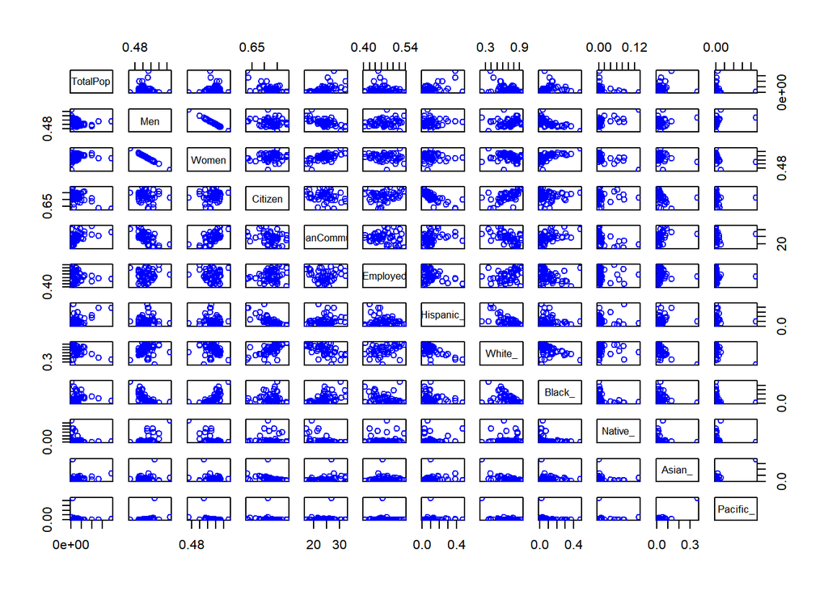

```r
plot(X_state[,2:13], col='blue')
```

In the next correlogram, it is obvious that Poverty and ChildPoverty are highly positively correlated. This also is intuitive because the children of parents in poverty will be in poverty as well.

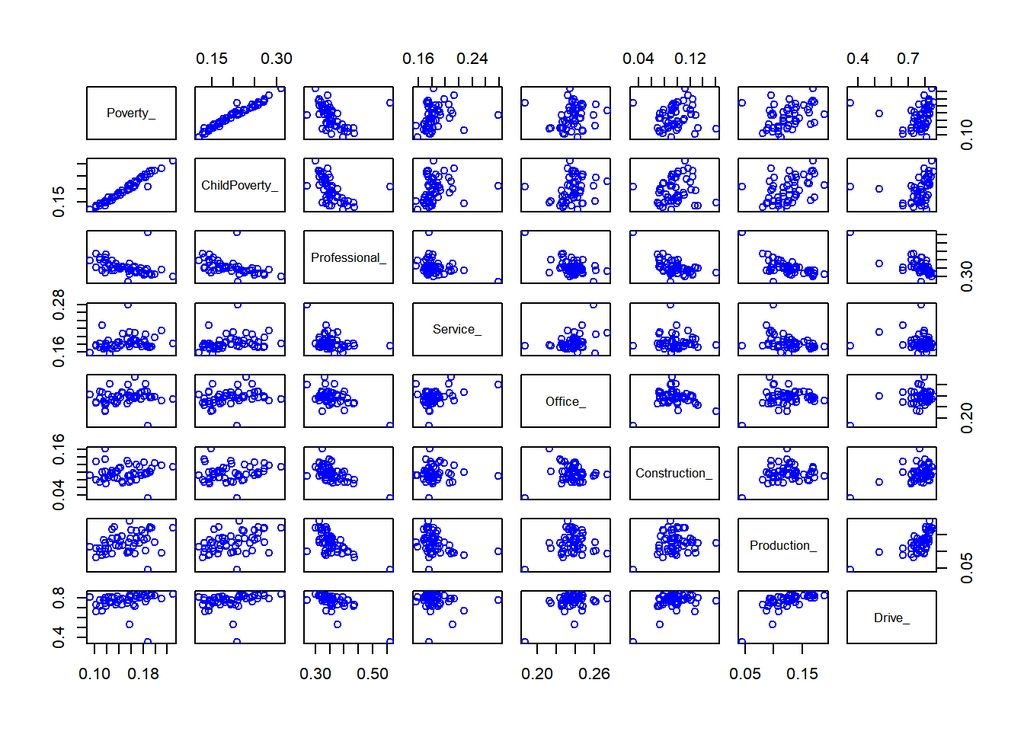

```r
plot(X_state[,14:21], col='blue')
```

No super strong correlations pop out in the last correlogram, except possibly a negative correlation between the proportion of people in the private versus public sector. That does not mean that there are no other strong correlations in the data set, because the correlogram for the entire data set was too large to visualize.

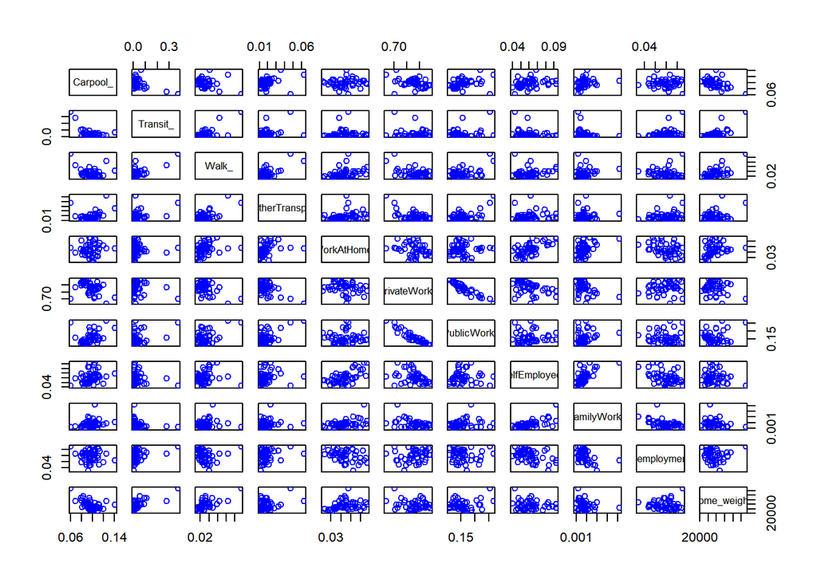

```r
plot(X_state[,22:32], col='blue')
```

Using a function to identify highly correlated (|correlation| > 0.9) features for removal, identified 2 features we identified visually for removal (Men, Poverty), as well 2 other redundant variables we did not identify (Carpool and WorkAtHome). After removing the redundant variables and recalculating the correlations, Drive and OtherTransp were identified as redundant due to strong correlations with other variables, so they were removed as well.

```r
# imports caret to identify corrleated features
library(caret)
# finds correlated features with threshold 0.9
state_correlated_features = findCorrelation(cor(X_state[,-1]), cutoff = 0.9, exact = T)

while (is.null(colnames(X_state[,state_correlated_features])) == F) {
  # finds correlated features with threshold 0.9
  state_correlated_features = findCorrelation(cor(X_state[,-1]), cutoff = 0.9, exact = T)
  # prints the name of correlated features
  print(colnames(X_state[,state_correlated_features]))
  # removes the highly correlated variables
  X_state = X_state[,-state_correlated_features]
}
```

```
## [1] "Carpool_"    "Men"         "Poverty_"    "WorkAtHome_"
## [1] "Drive_"       "OtherTransp_"
## NULL
```

### **ii. County Level**

Instead of repeating the correlograms at the county level, I just removed the redundant features with correlations greater than or equal to 0.9 in magnitude, which was Men and Poverty again. Now that redundant variables were removed from the data sets, I moved on to exploratory analysis.

```r
# finds correlated features with threshold 0.85
county_correlated_features = findCorrelation(cor(X_county[,-1]), cutoff = 0.9, exact = T)

# prints the name of correlated features
colnames(X_county[,county_correlated_features])
```

```
## [1] "Poverty_" "Men"
```

```r
# removes the highly correlated variables
X_county = X_county[,-county_correlated_features]
```

## **B. Principal Component Analysis and K-means Clustering**

I used k-means clustering to identify which states are similar to each other based on the remaining features contained in the ACS. The issue was there are 24 independent variables for the state level and 29 for the county level, which is where the curse of dimensionality reared its head. In 24-dimensional space (or 29-dimensional space) similar data points can be very far apart. For that reason, I used Principal Components Analysis to reduce the number of dimensions for which clustering was performed on.

### **i. State Level Analysis**

Performing Principal Component Analysis on the state level independent variables showed about 79.4% of the variance in the independent variables is explained by the first 5 principal components. The fifth principal component is also the last principal component that explains more than 5% of the variance in the independent variables. I used that as an arbitrary cutting off point because I didn’t want to greatly exceed 4 dimensions for clustering.

```r
# performs principal component analysis on the the independent variables and scales them all to have mean 0 and standard deviation 1
pc.state.full = prcomp(X_state[, -1], scale = T)
# creates a variable that stores the percentage of variance explained by each principal component
pve.state.full = 100 * pc.state.full$sdev ^ 2 / sum(pc.state.full$sdev ^ 2)

summary(pc.state.full)
```

```
## Importance of components:
##                          PC1   PC2    PC3    PC4     PC5     PC6    PC7
## Standard deviation     2.455 2.202 1.9732 1.6045 1.30973 1.00575 0.9896
## Proportion of Variance 0.251 0.202 0.1622 0.1073 0.07147 0.04215 0.0408
## Cumulative Proportion  0.251 0.453 0.6153 0.7225 0.79401 0.83615 0.8770
##                            PC8     PC9    PC10    PC11    PC12    PC13
## Standard deviation     0.73572 0.68812 0.66144 0.59169 0.56822 0.49376
## Proportion of Variance 0.02255 0.01973 0.01823 0.01459 0.01345 0.01016
## Cumulative Proportion  0.89951 0.91924 0.93747 0.95206 0.96551 0.97567
##                          PC14    PC15    PC16   PC17    PC18   PC19
## Standard deviation     0.4544 0.32916 0.29843 0.2816 0.22002 0.1548
## Proportion of Variance 0.0086 0.00451 0.00371 0.0033 0.00202 0.0010
## Cumulative Proportion  0.9843 0.98879 0.99250 0.9958 0.99782 0.9988
##                           PC20    PC21    PC22      PC23      PC24
## Standard deviation     0.13060 0.10327 0.02576 0.0003907 0.0002829
## Proportion of Variance 0.00071 0.00044 0.00003 0.0000000 0.0000000
## Cumulative Proportion  0.99953 0.99997 1.00000 1.0000000 1.0000000
```

This Scree Plot visualizes the proportion of variance explained by each principal component. After the 5th one, the plot starts to bottom out in terms of the proportion of variance explained by the components.

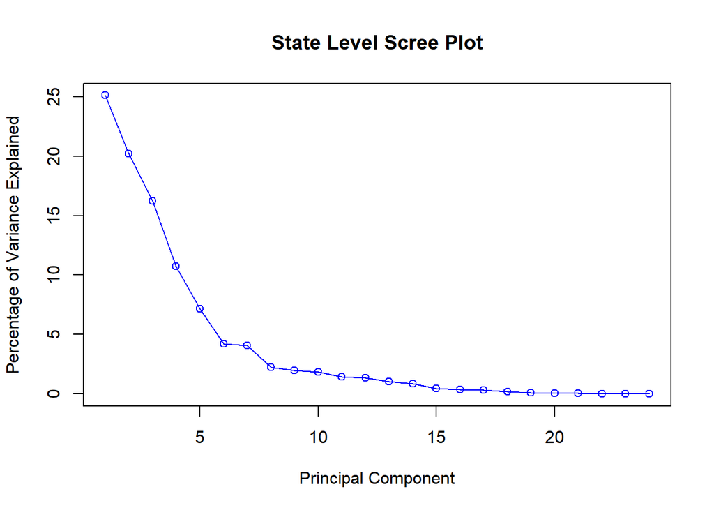

```r
# produces a scree plot for the state level data
plot(pve.state.full, type='o', main='State Level Scree Plot',
     ylab='Percentage of Variance Explained', xlab='Principal Component', col='blue')
```

This cumulative proportion of variance explained plot just illustrates that the cumulative percentage of variance explained is about 80% around the 5th principal component.

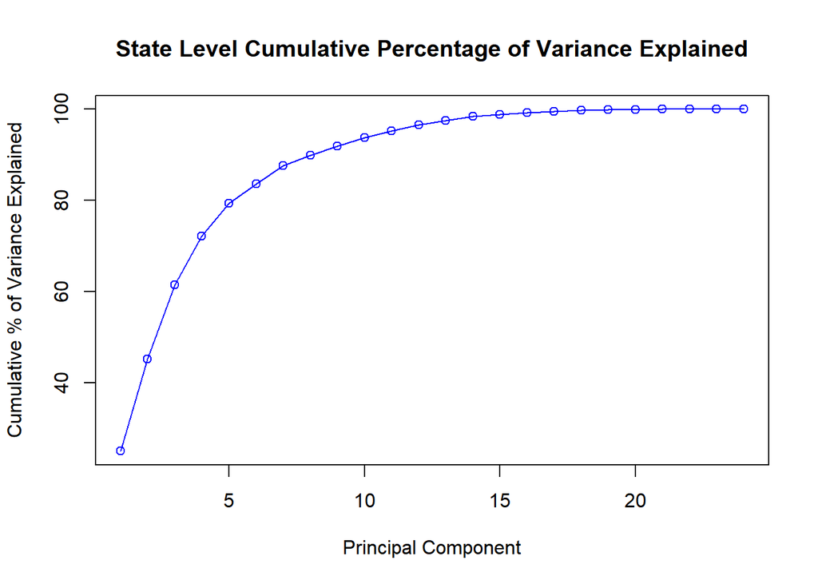

```r
# plots the cumulative percentage of variance explained by the principal components
plot(cumsum(pve.state.full), type='o', main='State Level Cumulative Percentage of Variance Explained',
     ylab='Cumulative % of Variance Explained', xlab='Principal Component', col='blue')
```

This plot shows the 1st and 2nd principal components plotted against each other with blue dots for Clinton wins and red dots for Trump wins. It looks like the observations are fairly well separated by the first 2 principal components.

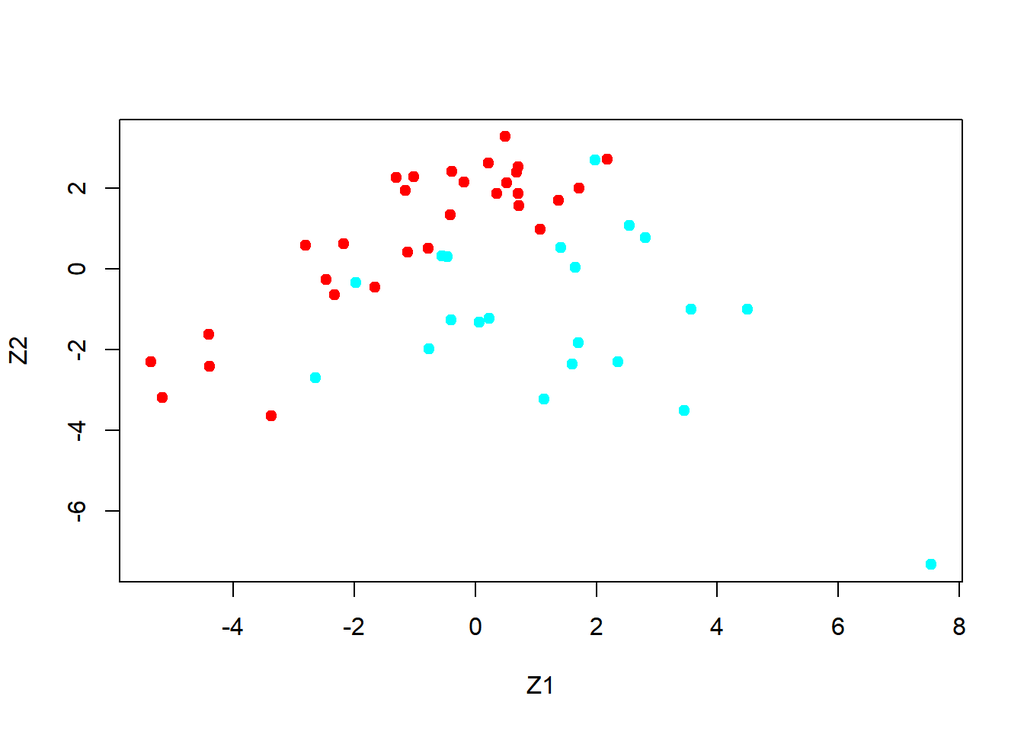

```r
# this is a function I got from the ISLR textbook to produce colors in plots for the target variable

# takes in a vector as an argument
Cols=function(vec){
  # uses the rainbow function to make a color for each unique value in the input vector and returns it
  cols = rainbow(length(unique(vec)))
  return(cols[as.numeric(as.factor(vec))])
}


# plots the 2 most important principal components against each other and assigns colors to the data points based on whether they voted for Clinton (Blue) or Trump (red)
plot(pc.state.full$x[,1:2], col=Cols(y_state$clinton_win), pch=19, xlab="Z1",ylab="Z2")
```

Next, I performed k-means clustering on the first 5 principal components with 2 to 10 clusters. I decided I liked the breakdown of the 10 cluster table the best because it allowed for small and large clusters, with most clusters containing 5 to 8 states. There are 3 single state clusters, 2 of which I expected to be Washington, DC (due to being 100% urban, with very high incomes, and high inequality one would expect it to be different from other states) and Hawaii (much larger Asian American and Pacific Islander population proportion than any other state and a much smaller proportion of white people). I decided not to try additional clusters because I did not want to create too small of clusters.

```r
# performs k-means clustering on the first 7 principal components with 2, 3, 4, and 5 clusters and prints out the result to compare the number of observations in each cluster with whether or not Trump or Clinton won there

# loops from 2 to 10
for (i in 2:10){
  # sets a seed for random number generation to make the results reproducible
  set.seed(1071)
  # does the k-means clustering with 20 starts to find a decent final clustering
  km.state.pca = kmeans(pc.state.full$x[,1:5], i, nstart = 20)
  # prints out a table of the clusters and the number of states in each one where Clinton won and lost
  print(table(km.state.pca$cluster, y_state$clinton_win))
}
```

```
##
##     FALSE TRUE
##   1    11    4
##   2    19   17
##
##     FALSE TRUE
##   1    18    7
##   2     0    8
##   3    12    6
##
##     FALSE TRUE
##   1    12    6
##   2     0    7
##   3     3    4
##   4    15    4
```

[output cut: 57 more lines]

Below is a visualization of the clusters and the difference between Clinton and Trump’s vote share.

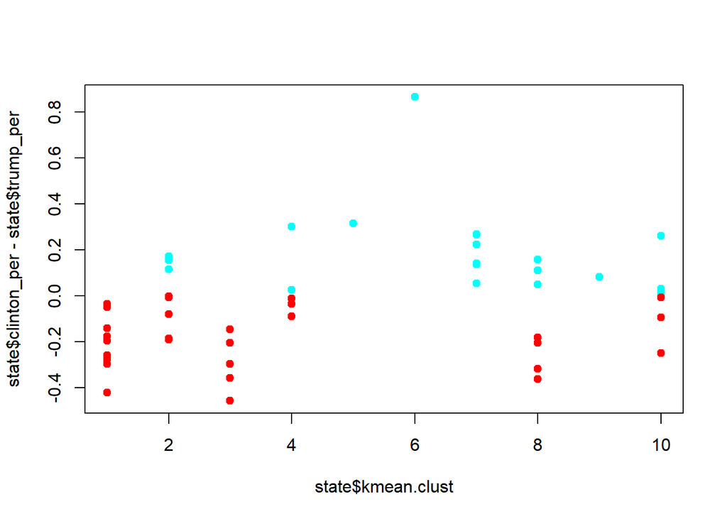

```r
# uses the same random seed as before
set.seed(1071)
# performs the k-means clustering with 10 clusters on the first 5 principal components with 50 starts
km.state.pca = kmeans(pc.state.full$x[,1:5], 10, nstart = 50)
# creates a column in states to hold the cluster assignments
state$kmean.clust = km.state.pca$cluster

# plots each cluster on the x-axis and the differential between Clinton and Trump's vote share to visualize the distribution of votes in each cluster (blue does above the 0 tick mark are states that voted Clinton)
plot(x = state$kmean.clust, y = state$clinton_per - state$trump_per, col = Cols(state$clinton_win), pch = 19)
```

The 1st cluster is the South. It seems to be the most similar cluster to what is considered to be the main regions of America (South, Southwest, Pacific Northwest, Mountain West, Great Plains, Upper Midwest, Mid-Atlantic, and New England). A notable exclusion is Virginia, which has seemed to join the Mid-Atlantic cluster.

The 2nd cluster stretches from Missouri in the west and Pennsylvania and Delaware in the east. It also has most of the ‘Rust Belt’ (Ohio, Michigan, Pennsylvania, and Indiana) within the cluster. Rhode Island seems out of place to me though.

The 4th cluster is interesting because it has 2 Clinton states (California and Nevada) and 3 Trump states (Texas, Florida, and Arizona), but it is easy to see how they are all connected. All of the states have very high Latinx populations and, excluding Florida, can be considered the Southwest. I would have expected New Mexico to be in this cluster as well, but using 10 clusters might have pulled it out.

As expected, Hawaii and DC have their own clusters.

The 7th cluster is interesting because it is made up of high GDP per capita states along the East Coast. Northern Virginia and Maryland are also where a lot of people who work in DC live, just as Connecticut and New Jersey have a fair amount of commuters to NYC.

The 8th cluster is made of the Mountain West and Pacific Northwest. It also contains a portion of the Mid-West.

New Mexico has its own cluster which surprised me as I expected it to be with other Southwestern states.

The final cluster is composed of the 3 northernmost New England states,the Upper Midwest sans Michigan, and Iowa and Nebraska. The last 4 states form a contiguous region, just as the first 3 form a continuous group of land.

```r
for (i in seq(unique(state$kmean.clust))){
  print(state %>%
          filter(kmean.clust == i) %>%
            select(State))
}
```

```
##             State
## 1         Alabama
## 2        Arkansas
## 3         Georgia
## 4        Kentucky
## 5       Louisiana
## 6     Mississippi
## 7  North Carolina
## 8  South Carolina
## 9       Tennessee
## 10  West Virginia
##          State
## 1     Delaware
## 2     Illinois
## 3      Indiana
```

[output cut: 46 more lines]

This is far from the final word in grouping US states together based on their characteristics. You could find more data about the states and perform different clusterings, even excluding DC and Hawaii since they are oultliers in terms of some of their characteristics, but I do think there were some interesting takeaways from this analysis. First, regions in the US are still strong. There was a high degree of geographical continuity within clusters. Second, Virginia is now closer to the Mid-Atlantic area than the South. Third, Alaska is fairly similar to the upper Great Plains. Finally, Florida is closer to the Southwest than the South, however this is likely driven by the high Latinx population. There are currently large differences between the high number of Americans of Cuban and Venezuelan descent in Florida and Latinx from other backgrounds in the area from California to Texas.

### **ii. County Level**

Compared to the state level, there is far more variability among counties than there was among states. It takes 11 principal components to explain the same amount of variance among counties as explained by 5 in the state data. Because of the high number of principal components required to explain more than 70% of the variance, I did not perform clustering on the counties.

```r
# performs principal component analysis on the the independent variables and scales them all to have mean 0 and standard deviation 1
pc.county.full = prcomp(X_county[, -1], scale = T)
# creates a variable that stores the percentage of variance explained by each principal component
pve.county.full = 100 * pc.county.full$sdev ^ 2 / sum(pc.county.full$sdev ^ 2)

summary(pc.county.full)
```

```
## Importance of components:
##                           PC1    PC2    PC3     PC4     PC5     PC6
## Standard deviation     2.2899 2.0625 1.8819 1.47547 1.22403 1.12870
## Proportion of Variance 0.1808 0.1467 0.1221 0.07507 0.05166 0.04393
## Cumulative Proportion  0.1808 0.3275 0.4496 0.52469 0.57636 0.62029
##                            PC7     PC8     PC9    PC10    PC11    PC12
## Standard deviation     1.10414 1.05443 0.97658 0.97049 0.94421 0.88124
## Proportion of Variance 0.04204 0.03834 0.03289 0.03248 0.03074 0.02678
## Cumulative Proportion  0.66232 0.70066 0.73355 0.76603 0.79677 0.82355
##                          PC13    PC14    PC15    PC16    PC17    PC18
## Standard deviation     0.8256 0.81544 0.76456 0.73302 0.68462 0.67163
## Proportion of Variance 0.0235 0.02293 0.02016 0.01853 0.01616 0.01555
## Cumulative Proportion  0.8470 0.86998 0.89014 0.90867 0.92483 0.94038
##                           PC19    PC20    PC21    PC22    PC23    PC24
## Standard deviation     0.60648 0.55329 0.51672 0.49849 0.47325 0.42914
## Proportion of Variance 0.01268 0.01056 0.00921 0.00857 0.00772 0.00635
## Cumulative Proportion  0.95307 0.96362 0.97283 0.98140 0.98912 0.99547
##                           PC25    PC26     PC27    PC28    PC29
## Standard deviation     0.35914 0.04818 0.004346 0.00324 0.00278
## Proportion of Variance 0.00445 0.00008 0.000000 0.00000 0.00000
## Cumulative Proportion  0.99992 1.00000 1.000000 1.00000 1.00000
```

Below: Scree Plot

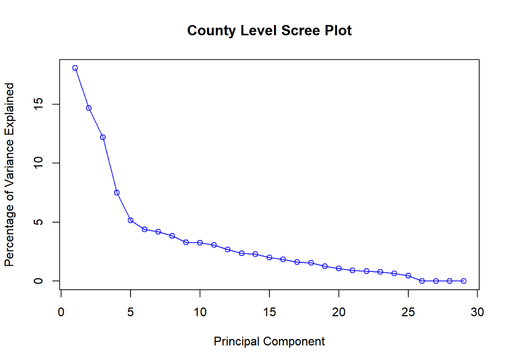

```r
# produces a scree plot for the County level
plot(pve.county.full, type='o', main='County Level Scree Plot',
     ylab='Percentage of Variance Explained', xlab='Principal Component', col='blue')
```

The cumulative percentage of variance explained plot shows how slowly the cumulative percentage of variance explained approaches 1.

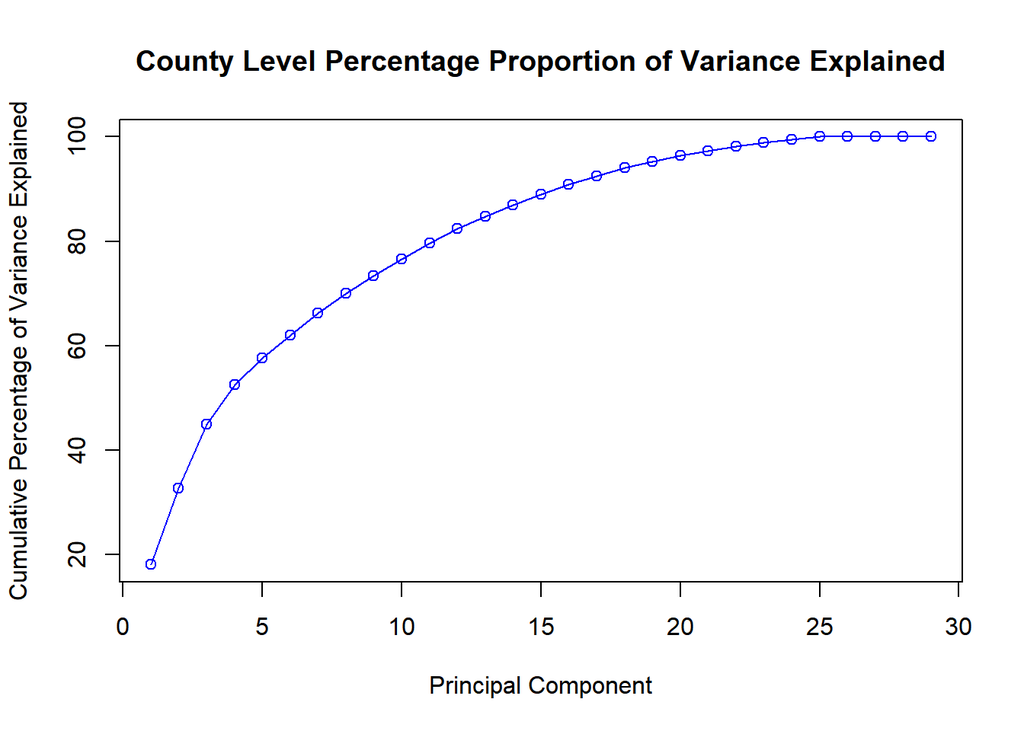

```r
# produces a plot of the cumulative percentage of variance explained
plot(cumsum(pve.county.full), type='o', main='County Level Percentage Proportion of Variance Explained',
     ylab='Cumulative Percentage of Variance Explained', xlab='Principal Component', col='blue')
```

As you can see from the 1st vs 2nd principal components, the separation of Trump and Clinton counties isn’t as clear as the separation using the first 2 principal components at the state level.

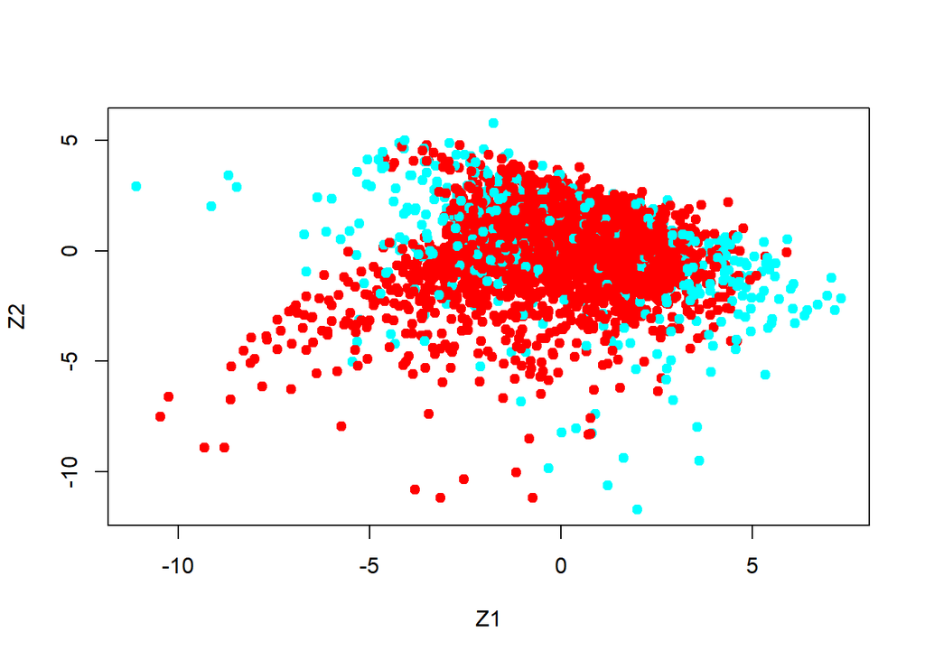

```r
# plots the 2 most important principal components and then color codes the data points based on election outcome
plot(pc.county.full$x[,1:2], col=Cols(y_county$clinton_win), pch=19, xlab="Z1",ylab="Z2")
```

# **III. Classification using Logistic Regression**

## **A. State Level**

The US has 50 states and DC, so the state level data set has 51 observations. It also has 24 independent variables. That means there are only about 2 observations for every observation. This means there wasn’t enough data to get reasonable standard errors of the coefficients and the statistical significance of each variable could not be determined.

Below is the output from performing logistic regression on the state level data. All of the z-values are zero due to having too few observations relative to independent variables.

```r
# creates a variable for whether Clinton won a state or not
state_clinton_win = y_state[,3]
# combines the variable above with the independent variables at the state level
state.class = cbind(state_clinton_win, X_state[,-1])
# estimates a logistic regression model for the state level with all variables; warnings are suppressed because some states are probabilities are predicted to be 1 or 0, which is consistent with prior expectations (Clinton had essentially 0% chance of winning Alabama by my guess)
suppressWarnings((log.state.full = glm(state_clinton_win~., family = 'binomial', data = state.class)))
```

```
##
## Call:  glm(formula = state_clinton_win ~ ., family = "binomial", data = state.class)
##
## Coefficients:
##     (Intercept)         TotalPop            Women          Citizen
##       4.687e+05       -1.300e-06        3.237e+03       -3.116e+02
##     MeanCommute         Employed        Hispanic_           White_
##       1.031e+01        2.108e+03       -1.095e+03       -1.109e+03
##          Black_          Native_           Asian_         Pacific_
##      -1.416e+03       -1.377e+03       -9.018e+02       -4.131e+03
##   ChildPoverty_    Professional_         Service_          Office_
##      -2.790e+02       -5.880e+04       -5.873e+04       -5.954e+04
##   Construction_      Production_         Transit_     PrivateWork_
##      -5.918e+04       -5.955e+04       -2.757e+02       -4.110e+05
##     PublicWork_    SelfEmployed_      FamilyWork_    Unemployment_
##      -4.104e+05       -4.113e+05       -4.050e+05        2.329e+03
## income_weighted
##      -1.168e-02
##
## Degrees of Freedom: 50 Total (i.e. Null);  26 Residual
## Null Deviance:       69.1
## Residual Deviance: 9.848e-10     AIC: 50
```

```r
# summarizes the model
summary(log.state.full)
```

```
##
## Call:
## glm(formula = state_clinton_win ~ ., family = "binomial", data = state.class)
##
## Deviance Residuals:
##        Min          1Q      Median          3Q         Max
## -1.122e-05  -2.110e-08  -2.110e-08   1.533e-06   1.096e-05
##
## Coefficients:
##                   Estimate Std. Error z value Pr(>|z|)
## (Intercept)      4.687e+05  3.698e+10       0        1
## TotalPop        -1.300e-06  9.660e-02       0        1
## Women            3.237e+03  6.752e+07       0        1
## Citizen         -3.116e+02  4.130e+07       0        1
## MeanCommute      1.031e+01  4.598e+05       0        1
## Employed         2.108e+03  4.128e+07       0        1
## Hispanic_       -1.095e+03  1.406e+07       0        1
## White_          -1.109e+03  1.598e+07       0        1
## Black_          -1.416e+03  2.013e+07       0        1
## Native_         -1.377e+03  3.027e+07       0        1
## Asian_          -9.018e+02  7.299e+07       0        1
## Pacific_        -4.131e+03  2.713e+08       0        1
## ChildPoverty_   -2.790e+02  4.179e+07       0        1
## Professional_   -5.880e+04  1.061e+10       0        1
## Service_        -5.873e+04  1.057e+10       0        1
## Office_         -5.954e+04  1.066e+10       0        1
## Construction_   -5.918e+04  1.064e+10       0        1
## Production_     -5.955e+04  1.059e+10       0        1
## Transit_        -2.757e+02  1.325e+07       0        1
## PrivateWork_    -4.110e+05  2.745e+10       0        1
## PublicWork_     -4.104e+05  2.745e+10       0        1
## SelfEmployed_   -4.113e+05  2.737e+10       0        1
## FamilyWork_     -4.050e+05  2.753e+10       0        1
## Unemployment_    2.329e+03  6.155e+07       0        1
## income_weighted -1.168e-02  2.089e+02       0        1
##
## (Dispersion parameter for binomial family taken to be 1)
##
##     Null deviance: 6.9104e+01  on 50  degrees of freedom
## Residual deviance: 9.8485e-10  on 26  degrees of freedom
## AIC: 50
##
## Number of Fisher Scoring iterations: 25
```

Because the z-values of the coefficients in the full model are all practically 0, I decided forward step-wise variable selection was preferable to backwards variable selection. However, at the end of the process, none of the variables selected were statistically significant. Since variables were added sequentially and the number of variables was small, I manually added the independent variables to the model until they lost statistical significance in the order they were listed in the output from the forward selection method.

```r
# creates an empty model for forwards step-wise regression
null.model <- glm(state_clinton_win ~ 1, family = 'binomial', data = state.class)
# performs forward stepwise regression for variable selection; warnings are suppressed because some states are probabilities are predicted to be 1 or 0, which is consistent with prior expectations (Clinton had essentially 0% chance of winning Alabama by my guess)
suppressWarnings((log.state.forwards = step(null.model, scope = list(lower=formula(null.model), upper = formula(log.state.full)), direction="forward", trace = 0)))
```

```
##
## Call:  glm(formula = state_clinton_win ~ income_weighted + Service_ +
##     Professional_ + FamilyWork_ + PrivateWork_, family = "binomial",
##     data = state.class)
##
## Coefficients:
##     (Intercept)  income_weighted         Service_    Professional_
##      -4.148e+03       -8.676e-03        1.380e+04        1.571e+04
##     FamilyWork_     PrivateWork_
##      -9.133e+05       -2.836e+03
##
## Degrees of Freedom: 50 Total (i.e. Null);  45 Residual
## Null Deviance:       69.1
## Residual Deviance: 1.039e-07     AIC: 12
```

```r
summary(log.state.forwards)
```

```
##
## Call:
## glm(formula = state_clinton_win ~ income_weighted + Service_ +
##     Professional_ + FamilyWork_ + PrivateWork_, family = "binomial",
##     data = state.class)
##
## Deviance Residuals:
##        Min          1Q      Median          3Q         Max
## -1.849e-04  -2.100e-08  -2.100e-08   2.100e-08   1.701e-04
##
## Coefficients:
##                   Estimate Std. Error z value Pr(>|z|)
## (Intercept)     -4.148e+03  6.504e+05  -0.006    0.995
## income_weighted -8.676e-03  4.069e+00  -0.002    0.998
## Service_         1.380e+04  1.998e+06   0.007    0.994
## Professional_    1.571e+04  2.449e+06   0.006    0.995
## FamilyWork_     -9.133e+05  1.436e+08  -0.006    0.995
## PrivateWork_    -2.836e+03  4.711e+05  -0.006    0.995
##
## (Dispersion parameter for binomial family taken to be 1)
##
##     Null deviance: 6.9104e+01  on 50  degrees of freedom
## Residual deviance: 1.0393e-07  on 45  degrees of freedom
## AIC: 12
##
## Number of Fisher Scoring iterations: 25
```

This left just 2 statistically significant variables, both of which positively affected the probability a state voted for Clinton as they increased; the income per capita of the state and the proportion of workers employed in the service sector.

```r
# after some messing around, there are only 2 variables that remain statistically significant and this is the model including them
log.state.mixed = glm(state_clinton_win ~ income_weighted + Service_, family = 'binomial', data = state.class)
# summarizes the model
summary(log.state.mixed)
```

```
##
## Call:
## glm(formula = state_clinton_win ~ income_weighted + Service_,
##     family = "binomial", data = state.class)
##
## Deviance Residuals:
##      Min        1Q    Median        3Q       Max
## -2.25541  -0.38610  -0.09241   0.19262   1.68880
##
## Coefficients:
##                   Estimate Std. Error z value Pr(>|z|)
## (Intercept)     -4.336e+01  1.464e+01  -2.962 0.003053 **
## income_weighted  7.806e-04  2.331e-04   3.348 0.000813 ***
## Service_         1.107e+02  4.909e+01   2.256 0.024092 *
## ---
## Signif. codes:  0 '***' 0.001 '**' 0.01 '*' 0.05 '.' 0.1 ' ' 1
##
## (Dispersion parameter for binomial family taken to be 1)
##
##     Null deviance: 69.104  on 50  degrees of freedom
## Residual deviance: 29.528  on 48  degrees of freedom
## AIC: 35.528
##
## Number of Fisher Scoring iterations: 7
```

This model had about a 13.7% error rate, or 7 out of 51, error rate on training data, but error rates on out of sample predictions is much more telling of model quality.

```r
# tests the model on training data

# produces the predicted probabilities for the training data
probs = predict(log.state.mixed, type = 'response')
# creeates a vecotr of TRUE values the length of the training data
preds = rep(TRUE, nrow(state.class))
# replaces TRUE with FALSE where the predicted probability of TRUE is less than 0.5
preds[probs < 0.5] = FALSE
# creates a confustion matrix for the training data
log.state.conf.mat = table(preds, y_state$clinton_win)
# converts the units in the confusion matrix from number of states to proportion of states
log.state.conf.mat / nrow(state.class)
```

```
##
## preds        FALSE       TRUE
##   FALSE 0.52941176 0.07843137
##   TRUE  0.05882353 0.33333333
```

Performing 5-fold cross validation using the model specified above yields a 16% mis-classification rate, with 3x more false negatives than false positives. This suggests the model is biased against predicting Clinton victories. To determine if the 16% error rate is good, I compared it to the baseline of predicting all observations as the modal outcome of the election outcomes in the 50 states plus DC. Clinton won 20 states and DC to the error rate of predicting the modal outcome is 21/51, or about 41%. This means the 2 variable model is an improvement over simply predicting the modal outcome.

```r
# this following block creates a function that performs k-folds cross validation on the classification models in glm

# takes in a dataframe WHOSE FIRST COLUMN MUST BE THE DEPENDENDENT VARIABLE, a formula, the number of folds to use, and the family argument for the glm function (for logistic regression, input binomial)
glm_cv = function(data, formula, folds, mod_type){

  # sets a random seed for reproducibility
  set.seed(1071)

  # creates an empty vectors to hold the number of false positives and negatives, and the true positives and negatives for each of the k-folds
  false_pos = c()
  false_neg = c()
  true_pos = c()
  true_neg = c()

  # creates the variable k equal to folds, because it is easier to type
  k = folds

  # starts a loop that goes from one to k
  for (i in 1:k){

    # creates a column of the indices between 1 and the last index of the input dataframe, sampled randomly without replacement, and of length number of rows divided by k and rounded to the nearest integer
    test = sample(1:nrow(data), round(nrow(data) / k) ,rep = F)
    # fits a model on the input data withholding the test data
    mod.temp = glm(formula, family = mod_type, data = data[-test,])
    # predicts the probabilities of the testing data set with the just fit model
    probs = predict(mod.temp, newdata = data[test, -1], type = 'response')
    # creeates a vecotr of TRUE values the length of the testing data
    preds = rep(TRUE, round(nrow(data) / k))
    # replaces TRUE with FALSE where the predicted probability of TRUE is less than 0.5
    preds[probs < 0.5] = FALSE
    # creates a confustion matrix for the test data
    confusion_matrix = table(preds, data[test, 1])

    # appends the true postives, etc to their corresponding vectors
    false_pos = append(false_pos, confusion_matrix[2,1])
    false_neg = append(false_neg, confusion_matrix[1,2])
    true_pos = append(true_pos, confusion_matrix[2,2])
    true_neg = append(true_neg, confusion_matrix[1,1])
  }
  # binds all the vectors by column, so each row is holds the number of true negatives etc for each fold
  mod.cv = cbind(true_neg, false_neg, false_pos, true_pos)

  # sums up each column (type of prediction like true positive) and divides that by the total number of prediction and overwrites the variable its named for
  true_neg = sum(mod.cv[,1]) / sum(mod.cv[,])
  false_neg = sum(mod.cv[,2]) / sum(mod.cv[,])
  false_pos = sum(mod.cv[,3]) / sum(mod.cv[,])
  true_pos = sum(mod.cv[,4]) / sum(mod.cv[,])

  # creates a row of the predicted FALSES
  pred_false = cbind(true_neg, false_neg)
  # creates a row of predicted TRUES
  pred_true = cbind(false_pos, true_pos)
  # binds them together to produce a confusion matrix
  cv.confusiom.matrix = rbind(pred_false, pred_true)
  # changes the row and column names of the confusion matrix for easier interpretability
  colnames(cv.confusiom.matrix) = c('FALSE', 'TRUE')
  row.names(cv.confusiom.matrix) = c('FALSE', 'TRUE')

  # returns the confusion matrix of the cross validated predictions
  return(cv.confusiom.matrix)
}

# performs k-forlds cross validation on the mixed stepwise selected model at the state level
print(glm_cv(state.class, log.state.mixed$formula, 5, 'binomial'))
```

```
##       FALSE TRUE
## FALSE  0.48 0.12
## TRUE   0.04 0.36
```

Because there are only so many states, it is impossible to estimate the significance for more than a couple of the features in the ACS on electoral outcomes. More observations are required, which is why I created a data set for the county level data as well.

### **ii. County Level**

In the model estimated on all the features in the county data set, a significant portion of the independent variables are significant at the 95% significance level and even more are not. To keep only variables I am fairly certain affect election outcome, I used both forwards and backwards variable selection. I decided to not use best subset selection because the number of calculations that would require with almost 30 independent variables is very high.

```r
# creates a variable for whether Clinton won a county or not
county_clinton_win = y_county[,3]
# combines the variable above with the independent variables at the county level
county.class = cbind(county_clinton_win, X_county[,-1])
# estimates a logistic regression model for the county level with all variables
suppressWarnings((log.county.full = glm(county_clinton_win~., family = 'binomial', data = county.class)))
```

```
##
## Call:  glm(formula = county_clinton_win ~ ., family = "binomial", data = county.class)
##
## Coefficients:
##     (Intercept)         TotalPop            Women          Citizen
##      -1.037e+03        1.748e-07        3.877e-01        1.313e+01
##     MeanCommute         Employed        Hispanic_           White_
##       2.264e-02        2.004e+01       -3.949e+00       -1.636e+01
##          Black_          Native_           Asian_         Pacific_
##      -3.206e+00       -6.491e+00        4.262e+00        8.777e+01
##   ChildPoverty_    Professional_         Service_          Office_
##       3.408e+00        5.787e+00        1.596e+01       -1.384e+01
##   Construction_      Production_           Drive_         Carpool_
##      -1.825e+01       -4.901e+00        5.273e+02        5.269e+02
##        Transit_            Walk_     OtherTransp_      WorkAtHome_
##       5.500e+02        5.485e+02        5.377e+02        5.315e+02
##    PrivateWork_      PublicWork_    SelfEmployed_      FamilyWork_
##       4.991e+02        4.915e+02        4.940e+02        4.179e+02
##   Unemployment_  income_weighted
##       1.841e+01        5.094e-05
##
## Degrees of Freedom: 3045 Total (i.e. Null);  3016 Residual
## Null Deviance:       2637
## Residual Deviance: 1040  AIC: 1100
```

```r
# summarizes the model
summary(log.county.full)
```

```
##
## Call:
## glm(formula = county_clinton_win ~ ., family = "binomial", data = county.class)
##
## Deviance Residuals:
##     Min       1Q   Median       3Q      Max
## -3.7096  -0.2512  -0.1035  -0.0393   3.6406
##
## Coefficients:
##                   Estimate Std. Error z value Pr(>|z|)
## (Intercept)     -1.037e+03  4.451e+02  -2.330  0.01980 *
## TotalPop         1.748e-07  3.536e-07   0.494  0.62102
## Women            3.877e-01  3.883e+00   0.100  0.92046
## Citizen          1.313e+01  2.643e+00   4.966 6.82e-07 ***
## MeanCommute      2.264e-02  2.005e-02   1.129  0.25882
## Employed         2.004e+01  2.880e+00   6.961 3.38e-12 ***
## Hispanic_       -3.949e+00  6.086e+00  -0.649  0.51643
## White_          -1.636e+01  6.284e+00  -2.604  0.00922 **
## Black_          -3.206e+00  6.109e+00  -0.525  0.59971
## Native_         -6.491e+00  6.474e+00  -1.003  0.31604
## Asian_           4.262e+00  9.370e+00   0.455  0.64924
## Pacific_         8.777e+01  4.072e+01   2.155  0.03114 *
## ChildPoverty_    3.408e+00  1.530e+00   2.227  0.02592 *
## Professional_    5.787e+00  2.772e+02   0.021  0.98334
## Service_         1.596e+01  2.771e+02   0.058  0.95406
## Office_         -1.384e+01  2.768e+02  -0.050  0.96012
## Construction_   -1.825e+01  2.772e+02  -0.066  0.94750
## Production_     -4.901e+00  2.773e+02  -0.018  0.98590
## Drive_           5.273e+02  1.969e+02   2.678  0.00741 **
## Carpool_         5.269e+02  1.971e+02   2.674  0.00751 **
## Transit_         5.500e+02  1.964e+02   2.800  0.00511 **
## Walk_            5.485e+02  1.969e+02   2.786  0.00534 **
## OtherTransp_     5.377e+02  1.966e+02   2.735  0.00624 **
## WorkAtHome_      5.315e+02  1.977e+02   2.689  0.00717 **
## PrivateWork_     4.991e+02  3.131e+02   1.594  0.11090
## PublicWork_      4.915e+02  3.132e+02   1.569  0.11655
## SelfEmployed_    4.940e+02  3.131e+02   1.578  0.11461
## FamilyWork_      4.179e+02  3.149e+02   1.327  0.18449
## Unemployment_    1.841e+01  3.460e+00   5.319 1.04e-07 ***
## income_weighted  5.094e-05  2.921e-05   1.744  0.08119 .
## ---
## Signif. codes:  0 '***' 0.001 '**' 0.01 '*' 0.05 '.' 0.1 ' ' 1
##
## (Dispersion parameter for binomial family taken to be 1)
##
##     Null deviance: 2637.1  on 3045  degrees of freedom
## Residual deviance: 1040.2  on 3016  degrees of freedom
## AIC: 1100.2
##
## Number of Fisher Scoring iterations: 7
```

In the model selected with backwards selection, 6 independent variables have been eliminated from the full model. In addition, some interesting relationships show up. Some are difficult to develop explanations for and some come with plausible explanations. Some are counter-intuitive.

The most glaring example of a counter-intuitive relationship is that increases in the black population in a state is associated with a decrease in likelihood of a Clinton victory in that county, despite the exit polls suggesting black voters overwhelmingly supporting Clinton. This is an illustration that correlation does not imply correlation. This may be caused by the South having a large population of black people, but still leaning heavily Republican overall. A similar story can be told for the negative coefficient for Native Americans. They reside disproportionately in the heavily Republican Midwest. A higher proportion of white people in a county is associated with a decrease in the likelihood of a Clinton victory according to the model. This is consistent with white people voting for Republicans more often than for Democrats.

Secretary Clinton’s chances of victory increased in counties with high unemployment rates and child poverty rates. They also increased in counties with higher incomes per capita. This suggests to me she won poorer counties and richer counties, suggesting she did well where people were making more money (which correlates with higher education levels and urbanization) and where people were hurting economically. This may mean she did well with those worst off and best off.

A pair of variables that positively affected Clinton’s chances of winning a county, according to the model, are taking public transport and walking to work. These are modes of commuting most common in urban areas and seem to be a proxy of the degree of urbanization of a county.

```r
# performs backwards stepwise regression for variable selection
suppressWarnings((log.county.backwards = step(log.county.full, trace = 0)))
```

```
##
## Call:  glm(formula = county_clinton_win ~ Citizen + Employed + Hispanic_ +
##     White_ + Black_ + Native_ + Pacific_ + ChildPoverty_ + Professional_ +
##     Service_ + Office_ + Construction_ + Drive_ + Carpool_ +
##     Transit_ + Walk_ + OtherTransp_ + WorkAtHome_ + PrivateWork_ +
##     PublicWork_ + SelfEmployed_ + Unemployment_ + income_weighted,
##     family = "binomial", data = county.class)
##
## Coefficients:
##     (Intercept)          Citizen         Employed        Hispanic_
##      -6.449e+02        1.292e+01        1.969e+01       -6.423e+00
##          White_           Black_          Native_         Pacific_
##      -1.893e+01       -5.452e+00       -9.157e+00        8.553e+01
##   ChildPoverty_    Professional_         Service_          Office_
##       3.016e+00        1.091e+01        2.057e+01       -8.738e+00
##   Construction_           Drive_         Carpool_         Transit_
##      -1.290e+01        5.445e+02        5.447e+02        5.694e+02
##           Walk_     OtherTransp_      WorkAtHome_     PrivateWork_
##       5.646e+02        5.541e+02        5.499e+02        8.809e+01
##     PublicWork_    SelfEmployed_    Unemployment_  income_weighted
##       8.004e+01        8.233e+01        1.917e+01        5.694e-05
##
## Degrees of Freedom: 3045 Total (i.e. Null);  3022 Residual
## Null Deviance:       2637
## Residual Deviance: 1044  AIC: 1092
```

```r
summary(log.county.backwards)
```

```
##
## Call:
## glm(formula = county_clinton_win ~ Citizen + Employed + Hispanic_ +
##     White_ + Black_ + Native_ + Pacific_ + ChildPoverty_ + Professional_ +
##     Service_ + Office_ + Construction_ + Drive_ + Carpool_ +
##     Transit_ + Walk_ + OtherTransp_ + WorkAtHome_ + PrivateWork_ +
##     PublicWork_ + SelfEmployed_ + Unemployment_ + income_weighted,
##     family = "binomial", data = county.class)
##
## Deviance Residuals:
##     Min       1Q   Median       3Q      Max
## -3.7293  -0.2529  -0.1031  -0.0376   3.6767
##
## Coefficients:
##                   Estimate Std. Error z value Pr(>|z|)
## (Intercept)     -6.449e+02  2.056e+02  -3.136 0.001714 **
## Citizen          1.292e+01  2.565e+00   5.037 4.73e-07 ***
## Employed         1.969e+01  2.715e+00   7.251 4.14e-13 ***
## Hispanic_       -6.423e+00  3.797e+00  -1.692 0.090729 .
## White_          -1.893e+01  3.924e+00  -4.825 1.40e-06 ***
## Black_          -5.452e+00  3.816e+00  -1.429 0.153097
## Native_         -9.157e+00  4.009e+00  -2.284 0.022354 *
## Pacific_         8.553e+01  3.979e+01   2.149 0.031607 *
## ChildPoverty_    3.016e+00  1.464e+00   2.060 0.039359 *
## Professional_    1.091e+01  2.773e+00   3.933 8.37e-05 ***
## Service_         2.057e+01  3.367e+00   6.109 1.00e-09 ***
## Office_         -8.738e+00  3.704e+00  -2.359 0.018327 *
## Construction_   -1.290e+01  3.733e+00  -3.454 0.000551 ***
## Drive_           5.445e+02  1.990e+02   2.737 0.006209 **
## Carpool_         5.447e+02  1.992e+02   2.734 0.006251 **
## Transit_         5.694e+02  1.985e+02   2.869 0.004122 **
## Walk_            5.646e+02  1.990e+02   2.838 0.004543 **
## OtherTransp_     5.541e+02  1.987e+02   2.789 0.005294 **
## WorkAtHome_      5.499e+02  1.998e+02   2.753 0.005907 **
## PrivateWork_     8.809e+01  3.570e+01   2.467 0.013608 *
## PublicWork_      8.004e+01  3.583e+01   2.234 0.025500 *
## SelfEmployed_    8.233e+01  3.663e+01   2.247 0.024612 *
## Unemployment_    1.917e+01  3.390e+00   5.656 1.55e-08 ***
## income_weighted  5.694e-05  2.842e-05   2.003 0.045140 *
## ---
## Signif. codes:  0 '***' 0.001 '**' 0.01 '*' 0.05 '.' 0.1 ' ' 1
##
## (Dispersion parameter for binomial family taken to be 1)
##
##     Null deviance: 2637.1  on 3045  degrees of freedom
## Residual deviance: 1043.8  on 3022  degrees of freedom
## AIC: 1091.8
##
## Number of Fisher Scoring iterations: 7
```

I evaluated this model using 5-fold cross validation and used the error rate of predicting the modal outcome as the baseline comparison rate. That baseline is about 15.6% in my data set missing a couple counties/boroughs. The mis-classification rate of the model selected with backwards selection is about 6.8%, which is less than half the baseline error rate. The rate of false negatives is about 3.9% compared to 2.8% rate of false positives, suggesting the possibility the model is slightly biased towards predicting a Clinton loss.

```r
sum(county.class$county_clinton_win == T)/length(county.class$county_clinton_win)
```

```
## [1] 0.1559422
```

```r
# performs k-forlds cross validation on the backwards stepwise selected model at the county level
print(suppressWarnings((glm_cv(county.class, log.county.backwards$formula, 5, 'binomial'))))
```

```
##            FALSE       TRUE
## FALSE 0.82561576 0.03940887
## TRUE  0.02824302 0.10673235
```

The model selected by forwards selection has many of the same variables as the model selected using backwards selection and the direction of coefficients remains the same. However, without the variables for the proportion of black and Hispanic people (it is possible other factors are causing this change, but I assume it is these because they are racial variables)in a county, the z-value for the coefficient of white jumps up to -16.068, which is really large.

```r
# creates an empty model for forwards step-wise regression
null.mod <- glm(county_clinton_win ~ 1, family = 'binomial', data = county.class)
# performs forward stepwise regression for variable selection
suppressWarnings((log.county.forwards = step(null.mod, scope = list(lower=formula(null.mod), upper = formula(log.county.full)), direction='forward', trace = 0)))
```

```
##
## Call:  glm(formula = county_clinton_win ~ White_ + Construction_ + Transit_ +
##     Walk_ + income_weighted + Citizen + Employed + Unemployment_ +
##     Service_ + Native_ + Professional_ + PrivateWork_ + ChildPoverty_ +
##     Pacific_ + Office_ + FamilyWork_ + OtherTransp_, family = "binomial",
##     data = county.class)
##
## Coefficients:
##     (Intercept)           White_    Construction_         Transit_
##      -2.571e+01       -1.271e+01       -1.310e+01        2.672e+01
##           Walk_  income_weighted          Citizen         Employed
##       2.090e+01        6.686e-05        1.300e+01        1.935e+01
##   Unemployment_         Service_          Native_    Professional_
##       1.965e+01        1.876e+01       -2.987e+00        1.208e+01
##    PrivateWork_    ChildPoverty_         Pacific_          Office_
##       7.399e+00        3.717e+00        1.064e+02       -9.070e+00
##     FamilyWork_     OtherTransp_
##      -6.256e+01        1.205e+01
##
## Degrees of Freedom: 3045 Total (i.e. Null);  3028 Residual
## Null Deviance:       2637
## Residual Deviance: 1056  AIC: 1092
```

```r
summary(log.county.forwards)
```

```
##
## Call:
## glm(formula = county_clinton_win ~ White_ + Construction_ + Transit_ +
##     Walk_ + income_weighted + Citizen + Employed + Unemployment_ +
##     Service_ + Native_ + Professional_ + PrivateWork_ + ChildPoverty_ +
##     Pacific_ + Office_ + FamilyWork_ + OtherTransp_, family = "binomial",
##     data = county.class)
##
## Deviance Residuals:
##     Min       1Q   Median       3Q      Max
## -3.8338  -0.2515  -0.1061  -0.0405   3.6323
##
## Coefficients:
##                   Estimate Std. Error z value Pr(>|z|)
## (Intercept)     -2.571e+01  3.391e+00  -7.582 3.41e-14 ***
## White_          -1.271e+01  7.913e-01 -16.068  < 2e-16 ***
## Construction_   -1.310e+01  3.463e+00  -3.783 0.000155 ***
## Transit_         2.672e+01  6.289e+00   4.248 2.15e-05 ***
## Walk_            2.090e+01  3.587e+00   5.826 5.68e-09 ***
## income_weighted  6.686e-05  2.740e-05   2.440 0.014696 *
## Citizen          1.300e+01  2.043e+00   6.362 2.00e-10 ***
## Employed         1.935e+01  2.702e+00   7.160 8.08e-13 ***
## Unemployment_    1.965e+01  3.282e+00   5.986 2.16e-09 ***
## Service_         1.876e+01  2.998e+00   6.259 3.87e-10 ***
## Native_         -2.987e+00  1.092e+00  -2.735 0.006232 **
## Professional_    1.208e+01  2.628e+00   4.598 4.27e-06 ***
## PrivateWork_     7.399e+00  1.783e+00   4.150 3.33e-05 ***
## ChildPoverty_    3.717e+00  1.365e+00   2.723 0.006469 **
## Pacific_         1.064e+02  3.730e+01   2.852 0.004340 **
## Office_         -9.070e+00  3.594e+00  -2.523 0.011621 *
## FamilyWork_     -6.256e+01  3.467e+01  -1.804 0.071219 .
## OtherTransp_     1.205e+01  7.131e+00   1.690 0.090957 .
## ---
## Signif. codes:  0 '***' 0.001 '**' 0.01 '*' 0.05 '.' 0.1 ' ' 1
##
## (Dispersion parameter for binomial family taken to be 1)
##
##     Null deviance: 2637.1  on 3045  degrees of freedom
## Residual deviance: 1055.8  on 3028  degrees of freedom
## AIC: 1091.8
##
## Number of Fisher Scoring iterations: 7
```

```r
# performs k-forlds cross validation on the forwards stepwise selected model at the county level
print(suppressWarnings((glm_cv(county.class, log.county.forwards$formula, 5, 'binomial'))))
```

```
##            FALSE      TRUE
## FALSE 0.82791461 0.0407225
## TRUE  0.02594417 0.1054187
```

# **IV. Closing Thoughts**

I enjoyed working on a problem of election prediction, as it was how I first became interested in data. Although the logistic regressions outperformed simply guessing the modal outcome in the 2016 election, I believe they would not generalize well if trying to predict the 2020 election, as they would over fit to the 2016 election. I would include a couple cycles to get more observations and get models less sensitive to the idiosyncrasies of the 2016 election. I would also use the ACS data from the year of the election for better estimates of the effects of demographic factors on the election; even though I would have to rely on the 2019 ACS to make predictions for 2020.

Additionally, I would need a way to capture polls in a model. Using the 2 variable state level model reveals why that might be the case. The model had a few large misses *on the training data set!* Notably, all but Florida could be considered large misses for the model.

Below: Mis-Classified States from the training set estimation for the Mixed Selection State Level Model

```r
state %>%
  filter(preds != y_state$clinton_win) %>%
    select(State)
```

| State |
| --- |
| Alaska |
| Florida |
| Maine |
| New Mexico |
| North Dakota |
| Oregon |
| Vermont |

A model with more observations (from, say, 3 election cycles) could have enough degrees of freedom to allow for more variables and a better model. But, Colorado, Oregon, and Washington were put in the same cluster as Idaho, Kansas, Oklahoma and Utah based on the ACS data, despite having very different election outcomes. That may be a function of my particular number of clusters and random seed, but it may reflect that there is something more to voting patterns than only ACS data can predict, despite its usefulness. Accounting for demographic data and poll results would likely be an improvement over just relying on demographic data.

This project was quite enjoyable and generated several further avenues of inquiry. I hope to find the time to work on them. Thanks for reading.